# Catastrophising Questionnaire open code

This code runs the analyses reported in the paper presenting a novel Catastrophising Questionnaire (Serfaty, Pike, Robinson). Before you run this code, please note the following:

1. This code depends on libraries/functions written by other users. These are all listed in the chunk below. Some parts of the code will not run without installing these packages/sourcing these functions.
2. This code requires you to define a working directory, into which you should have already downloaded the data (from the ‘Open code’ folder in this OSF). This is done using the choose.dir() function, so will pop up automatically.
3. This code will save images (the figures from the paper) into your working directory. If you do not want to do this, please enter 0 into the pop-up box.

Load libraries that this depends on

```r
library('dplyr')
library('ggplot2')
library('lubridate')
library('psych')
library('corrr')
library('cowplot')
library('car')
library('reshape2')
library('pheatmap')
library('afex')
library('irr')
library('svDialogs')
source("https://gist.githubusercontent.com/benmarwick/2a1bb0133ff568cbe28d/raw/fb53bd97121f7f9ce947837ef1a4c65a73bffb3f/geom_flat_violin.R")
```

Set a working directory and define whether you want to save images

```r
workingdir=choose.dir()
save_images <- as.integer(dlgInput('Do you want to save images? 1=yes, 0=no: ', Sys.info()['0'])$res)
```

# Experiment 1

Load in the data

```r
data1<-read.csv(paste0(workingdir,'/experiment1.csv'))
```

Check how long the total experiment and questionnaire took

```r
cat_time_taken<-mean(data1$cat_questionnaire_time)
seconds_to_period(cat_time_taken/1000)
```

```
[1] "3M 53.7178290598291S"
```

```r
full_time_taken<-mean(data1$total_time)
seconds_to_period(full_time_taken)
```

```
[1] "6M 31.7007264957265S"
```

```r
data1_items<-data1[,c('X1','X2','X3','X4','X5','X6','X7','X8','X9','X10','X11','X12','X13','X14','X15','X16','X17','X18','X19','X20','X21','X22','X23','X24','X25','X26','X27','X28','X29','X30','X31')]
```

Do alpha, omega and inter-item and item-total correlations

```r
#alpha
psych::alpha(x=data1_items)
```

```
Reliability analysis
Call: psych::alpha(x = data1_items)
```

|  | raw_alpha | std.alpha | G6(smc) | average_r | S/N | ase | mean | sd | median_r |
| --- | --- | --- | --- | --- | --- | --- | --- | --- | --- |
|  | 0.9536881 | 0.9544522 | 0.9707444 | 0.4033293 | 20.95495 | 0.006125799 | 2.684864 | 0.7153854 | 0.4023898 |

```
 lower alpha upper     95% confidence boundaries
0.94 0.95 0.97

 Reliability if an item is dropped:
```

|  | raw_alpha | std.alpha | G6(smc) | average_r | S/N | alpha se | var.r | med.r |
| --- | --- | --- | --- | --- | --- | --- | --- | --- |
| X1 | 0.9519625 | 0.9527165 | 0.9693277 | 0.4017828 | 20.14901 | 0.006357982 | 0.01527605 | 0.3986760 |
| X2 | 0.9514331 | 0.9522506 | 0.9689243 | 0.3993114 | 19.94268 | 0.006429412 | 0.01495320 | 0.3986760 |
| X3 | 0.9518202 | 0.9525808 | 0.9687638 | 0.4010600 | 20.08849 | 0.006373641 | 0.01484748 | 0.3984414 |
| X4 | 0.9520333 | 0.9527678 | 0.9688883 | 0.4020569 | 20.17200 | 0.006349410 | 0.01481338 | 0.4007107 |
| X5 | 0.9514283 | 0.9522439 | 0.9690212 | 0.3992762 | 19.93975 | 0.006430277 | 0.01485966 | 0.3955972 |
| X6 | 0.9522377 | 0.9530313 | 0.9696183 | 0.4034689 | 20.29075 | 0.006319877 | 0.01521679 | 0.4025804 |
| X7 | 0.9518145 | 0.9526117 | 0.9690247 | 0.4012244 | 20.10225 | 0.006377009 | 0.01484765 | 0.3986760 |
| X8 | 0.9517814 | 0.9525339 | 0.9693134 | 0.4008108 | 20.06766 | 0.006382877 | 0.01526062 | 0.3955972 |
| X9 | 0.9526311 | 0.9533815 | 0.9695026 | 0.4053603 | 20.45072 | 0.006264908 | 0.01549938 | 0.4025804 |
| X10 | 0.9523281 | 0.9531552 | 0.9691518 | 0.4041362 | 20.34708 | 0.006303804 | 0.01552428 | 0.4023898 |

[output cut: 21 more lines]

```
 Item statistics
```

|  | n | raw.r | std.r | r.cor | r.drop | mean | sd |
| --- | --- | --- | --- | --- | --- | --- | --- |
| X1 | 117 | 0.6802458 | 0.6834405 | 0.6744906 | 0.6551061 | 2.905983 | 0.9911932 |
| X2 | 117 | 0.7339307 | 0.7367888 | 0.7324135 | 0.7086406 | 3.042735 | 1.1476600 |
| X3 | 117 | 0.6953393 | 0.6990425 | 0.6963479 | 0.6701831 | 3.435897 | 1.0287640 |
| X4 | 117 | 0.6735106 | 0.6775244 | 0.6732215 | 0.6487568 | 3.487179 | 0.9614589 |
| X5 | 117 | 0.7367855 | 0.7375494 | 0.7332311 | 0.7128404 | 3.401709 | 1.0990578 |
| X6 | 117 | 0.6447988 | 0.6470451 | 0.6351058 | 0.6141192 | 3.102564 | 1.1094004 |
| X7 | 117 | 0.6929739 | 0.6954937 | 0.6901166 | 0.6658318 | 3.222222 | 1.0994600 |
| X8 | 117 | 0.7010822 | 0.7044227 | 0.6950125 | 0.6766374 | 2.675214 | 1.0156454 |
| X9 | 117 | 0.6100055 | 0.6062158 | 0.5938143 | 0.5737630 | 2.393162 | 1.2173832 |
| X10 | 117 | 0.6336638 | 0.6326393 | 0.6237528 | 0.6029605 | 2.735043 | 1.0859063 |

[output cut: 21 more lines]

```
Non missing response frequency for each item
       1    2    3    4    5 miss
X1  0.07 0.28 0.38 0.22 0.05    0
X2  0.11 0.20 0.33 0.26 0.10    0
X3  0.03 0.14 0.35 0.32 0.16    0
X4  0.02 0.12 0.38 0.32 0.16    0
X5  0.03 0.22 0.26 0.32 0.18    0
X6  0.07 0.26 0.28 0.29 0.10    0
X7  0.07 0.19 0.32 0.31 0.12    0
X8  0.09 0.42 0.28 0.16 0.05    0
X9  0.28 0.31 0.21 0.13 0.07    0
X10 0.15 0.27 0.32 0.21 0.04    0
X11 0.25 0.24 0.31 0.19 0.02    0
X12 0.22 0.24 0.30 0.19 0.05    0
X13 0.43 0.26 0.19 0.09 0.03    0
X14 0.15 0.32 0.30 0.17 0.06    0
X15 0.32 0.33 0.17 0.09 0.09    0
X16 0.25 0.21 0.29 0.18 0.07    0
X17 0.32 0.27 0.19 0.20 0.03    0
X18 0.13 0.34 0.28 0.17 0.08    0
X19 0.19 0.38 0.29 0.12 0.03    0
X20 0.09 0.15 0.33 0.25 0.17    0
X21 0.26 0.33 0.29 0.10 0.02    0
X22 0.05 0.25 0.32 0.29 0.09    0
X23 0.30 0.37 0.21 0.09 0.03    0
X24 0.08 0.17 0.32 0.28 0.15    0
X25 0.25 0.40 0.20 0.12 0.03    0
X26 0.20 0.32 0.30 0.15 0.03    0
X27 0.41 0.25 0.15 0.16 0.03    0
X28 0.17 0.24 0.33 0.20 0.06    0
X29 0.19 0.26 0.36 0.15 0.04    0
X30 0.19 0.36 0.29 0.15 0.02    0
X31 0.50 0.27 0.15 0.03 0.04    0
```

```
Omega
Call: omegah(m = m, nfactors = nfactors, fm = fm, key = key, flip = flip,
    digits = digits, title = title, sl = sl, labels = labels,
    plot = plot, n.obs = n.obs, rotate = rotate, Phi = Phi, option = option,
    covar = covar)
Alpha:                 0.95
G.6:                   0.97
Omega Hierarchical:    0.76
Omega H asymptotic:    0.79
Omega Total            0.96

Schmid Leiman Factor loadings greater than  0.2
```

|  | g | F1* | F2* | F3* | h2 | u2 | p2 |
| --- | --- | --- | --- | --- | --- | --- | --- |
| X1 | 0.62 | 0.28 |  |  | 0.49 | 0.51 | 0.77 |
| X2 | 0.68 | 0.37 |  |  | 0.61 | 0.39 | 0.76 |
| X3 | 0.66 | 0.42 |  | 0.23 | 0.68 | 0.32 | 0.65 |
| X4 | 0.65 | 0.45 |  |  | 0.63 | 0.37 | 0.67 |
| X5 | 0.68 | 0.37 |  |  | 0.62 | 0.38 | 0.76 |
| X6 | 0.60 | 0.38 |  |  | 0.51 | 0.49 | 0.71 |
| X7 | 0.65 | 0.39 |  |  | 0.62 | 0.38 | 0.69 |
| X8 | 0.62 |  | 0.25 |  | 0.49 | 0.51 | 0.79 |
| X9 | 0.51 |  |  | 0.42 | 0.45 | 0.55 | 0.58 |
| X10 | 0.54 |  |  | 0.54 | 0.59 | 0.41 | 0.50 |

[output cut: 21 more lines]

```
With eigenvalues of:
   g  F1*  F2*  F3*
10.3  1.4  2.2  1.6

general/max  4.74   max/min =   1.51
mean percent general =  0.66    with sd =  0.12 and cv of  0.18
Explained Common Variance of the general factor =  0.66

The degrees of freedom are 375  and the fit is  4.9
The number of observations was  117  with Chi Square =  503.59  with prob <  9.8e-06
The root mean square of the residuals is  0.05
The df corrected root mean square of the residuals is  0.06
RMSEA index =  0.053  and the 10 % confidence intervals are  0.041 0.066
BIC =  -1282.23

Compare this with the adequacy of just a general factor and no group factors
The degrees of freedom for just the general factor are 434  and the fit is  7.57
The number of observations was  117  with Chi Square =  788.94  with prob <  5.8e-23
The root mean square of the residuals is  0.11
The df corrected root mean square of the residuals is  0.12

RMSEA index =  0.083  and the 10 % confidence intervals are  0.075 0.093
BIC =  -1277.84

Measures of factor score adequacy
                                                 g   F1*  F2*  F3*
Correlation of scores with factors            0.88  0.66 0.77 0.81
Multiple R square of scores with factors      0.78  0.44 0.59 0.65
Minimum correlation of factor score estimates 0.55 -0.13 0.17 0.31

 Total, General and Subset omega for each subset
                                                 g  F1*  F2*  F3*
Omega total for total scores and subscales    0.96 0.92 0.90 0.81
Omega general for total scores and subscales  0.76 0.71 0.61 0.53
Omega group for total scores and subscales    0.11 0.21 0.29 0.29
```

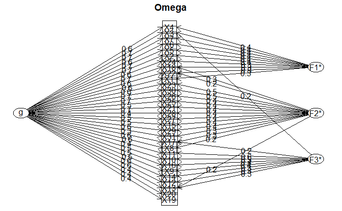

```r
#omega
psych::omega(data1_items)
```

```r
#inter-item correlation
data_correlation1 <- data1_items %>% corrr::correlate()
```

```
Correlation method: 'pearson'
Missing treated using: 'pairwise.complete.obs'
```

```r
data_correlation1 <- data_correlation1 %>% dplyr::select(-rowname) %>% colMeans(na.rm = TRUE)
data_correlation1
```

```
       X1        X2        X3        X4        X5        X6        X7        X8        X9       X10       X11
0.4257525 0.4615881 0.4362329 0.4217786 0.4620990 0.4013047 0.4338490 0.4398468 0.3738785 0.3916280 0.3036111
      X12       X13       X14       X15       X16       X17       X18       X19       X20       X21       X22
0.4140631 0.3324835 0.4344260 0.3423690 0.3846167 0.4258936 0.5018335 0.3247719 0.2717449 0.5064470 0.4411731
      X23       X24       X25       X26       X27       X28       X29       X30       X31
0.4275834 0.4356480 0.3749887 0.4722548 0.3930966 0.3131060 0.4567476 0.4697313 0.2286590
```

```r
mean(data_correlation1)
```

```
[1] 0.4033293
```

[figure not shown]

```r
data.frame(data_correlation1) %>%
  ggplot2::ggplot(aes(x = data_correlation1)) +
  geom_histogram(bins = 10, alpha = .5) +
  geom_vline(xintercept = mean(data_correlation1), color = "red") +
  xlab("Mean inter-item correlation") +
  theme_bw()
```

```r
#item-total correlation
data1_items$score<-rowSums(data1_items)
total_correlation1 <- data1_items %>% corrr::correlate() %>% focus(score)
```

```
Correlation method: 'pearson'
Missing treated using: 'pairwise.complete.obs'
```

```r
mean(total_correlation1$score)
```

```
[1] 0.6499805
```

Run an EFA and obtain the parameters recorded

```r
data1_items<- data1_items %>% dplyr::select(-'score')

psych::KMO(data1_items)
```

```
Kaiser-Meyer-Olkin factor adequacy
Call: psych::KMO(r = data1_items)
Overall MSA =  0.92
MSA for each item =
  X1   X2   X3   X4   X5   X6   X7   X8   X9  X10  X11  X12  X13  X14  X15  X16  X17  X18  X19  X20  X21  X22
0.94 0.94 0.92 0.91 0.96 0.94 0.93 0.95 0.88 0.88 0.83 0.95 0.90 0.93 0.89 0.88 0.94 0.93 0.94 0.85 0.93 0.92
 X23  X24  X25  X26  X27  X28  X29  X30  X31
0.91 0.94 0.91 0.93 0.92 0.86 0.93 0.92 0.84
```

```r
temp<-round(cor(data1_items),2)
cortest.bartlett(temp,n=nrow(data1_items))
```

```
$chisq
[1] 2245.726

$p.value
[1] 1.451003e-230

$df
[1] 465
```

```
Parallel analysis suggests that the number of factors =  3  and the number of components =  NA
```

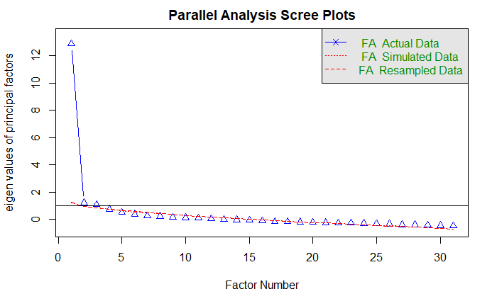

```r
parallel <- fa.parallel(data1_items, fm = 'minres', fa = 'fa')
```

```r
threefactor <- fa(data1_items,nfactors = 3,rotate = "oblimin",fm="minres")
print(threefactor)
```

```
Factor Analysis using method =  minres
Call: fa(r = data1_items, nfactors = 3, rotate = "oblimin", fm = "minres")
Standardized loadings (pattern matrix) based upon correlation matrix
```

|  | MR1 | MR2 | MR3 | h2 | u2 | com |
| --- | --- | --- | --- | --- | --- | --- |
| X1 | 0.09 | 0.50 | 0.22 | 0.4937404 | 0.5062596 | 1.436639 |
| X2 | 0.10 | 0.66 | 0.10 | 0.6084727 | 0.3915273 | 1.089085 |
| X3 | -0.18 | 0.75 | 0.28 | 0.6754492 | 0.3245508 | 1.393677 |
| X4 | -0.10 | 0.81 | 0.09 | 0.6299867 | 0.3700133 | 1.059005 |
| X5 | 0.18 | 0.66 | -0.01 | 0.6192015 | 0.3807985 | 1.151028 |
| X6 | 0.05 | 0.69 | -0.02 | 0.5132468 | 0.4867532 | 1.012475 |
| X7 | 0.22 | 0.70 | -0.16 | 0.6152748 | 0.3847252 | 1.313901 |
| X8 | 0.37 | 0.31 | 0.14 | 0.4874192 | 0.5125808 | 2.244049 |
| X9 | 0.16 | 0.09 | 0.52 | 0.4456638 | 0.5543362 | 1.264216 |
| X10 | 0.03 | 0.14 | 0.67 | 0.5850158 | 0.4149842 | 1.087472 |

[output cut: 21 more lines]

```
                       MR1  MR2  MR3
SS loadings           6.33 5.88 3.30
Proportion Var        0.20 0.19 0.11
Cumulative Var        0.20 0.39 0.50
Proportion Explained  0.41 0.38 0.21
Cumulative Proportion 0.41 0.79 1.00

 With factor correlations of
     MR1  MR2  MR3
MR1 1.00 0.63 0.45
MR2 0.63 1.00 0.50
MR3 0.45 0.50 1.00

Mean item complexity =  1.5
Test of the hypothesis that 3 factors are sufficient.

The degrees of freedom for the null model are  465  and the objective function was  21.37 with Chi Square of  2240.5
The degrees of freedom for the model are 375  and the objective function was  4.9

The root mean square of the residuals (RMSR) is  0.05
The df corrected root mean square of the residuals is  0.06

The harmonic number of observations is  117 with the empirical chi square  287.54  with prob <  1
The total number of observations was  117  with Likelihood Chi Square =  503.59  with prob <  9.8e-06

Tucker Lewis Index of factoring reliability =  0.908
RMSEA index =  0.053  and the 90 % confidence intervals are  0.041 0.066
BIC =  -1282.23
Fit based upon off diagonal values = 0.99
Measures of factor score adequacy
                                                   MR1  MR2  MR3
Correlation of (regression) scores with factors   0.96 0.96 0.91
Multiple R square of scores with factors          0.92 0.92 0.83
Minimum correlation of possible factor scores     0.84 0.85 0.67
```

# Experiment 2

```r
data2<-read.csv(paste0(workingdir,'/experiment2.csv'))
```

Check time taken

```r
cat_time_taken<-mean(data2$cat_questionnaire_time)
seconds_to_period(cat_time_taken/1000)
```

```
[1] "2M 34.9926495726496S"
```

```r
full_time_taken<-mean(data2$total_time)
seconds_to_period(full_time_taken)
```

```
[1] "6M 44.2187094017094S"
```

```r
data2_items<-data2[,c('X1','X2','X3','X4','X5','X6','X7','X8','X9','X10','X11','X12','X13','X14','X15','X16','X17','X18','X19','X20','X21','X22','X23','X24','X25')]
```

Do alpha, omega and inter-item and item-total correlations

```r
#alpha
psych::alpha(x=data2_items)
```

```
Reliability analysis
Call: psych::alpha(x = data2_items)
```

|  | raw_alpha | std.alpha | G6(smc) | average_r | S/N | ase | mean | sd | median_r |
| --- | --- | --- | --- | --- | --- | --- | --- | --- | --- |
|  | 0.932731 | 0.9341788 | 0.9530689 | 0.3621258 | 14.19268 | 0.008926609 | 2.559316 | 0.6642597 | 0.3663376 |

```
 lower alpha upper     95% confidence boundaries
0.92 0.93 0.95

 Reliability if an item is dropped:
```

|  | raw_alpha | std.alpha | G6(smc) | average_r | S/N | alpha se | var.r | med.r |
| --- | --- | --- | --- | --- | --- | --- | --- | --- |
| X1 | 0.9296299 | 0.9311935 | 0.9502581 | 0.3605713 | 13.53350 | 0.009346887 | 0.01394248 | 0.3673554 |
| X2 | 0.9301021 | 0.9316580 | 0.9510792 | 0.3622499 | 13.63230 | 0.009281875 | 0.01449583 | 0.3687823 |
| X3 | 0.9290295 | 0.9306993 | 0.9497092 | 0.3588007 | 13.42986 | 0.009433366 | 0.01383098 | 0.3610549 |
| X4 | 0.9280470 | 0.9296409 | 0.9491579 | 0.3550606 | 13.21280 | 0.009563111 | 0.01370339 | 0.3583901 |
| X5 | 0.9293879 | 0.9309663 | 0.9497809 | 0.3597555 | 13.48568 | 0.009373171 | 0.01426748 | 0.3621358 |
| X6 | 0.9297698 | 0.9313225 | 0.9502827 | 0.3610361 | 13.56081 | 0.009322827 | 0.01403592 | 0.3643877 |
| X7 | 0.9296780 | 0.9312239 | 0.9495652 | 0.3606809 | 13.53994 | 0.009338627 | 0.01367579 | 0.3626733 |
| X8 | 0.9287698 | 0.9303569 | 0.9489965 | 0.3575831 | 13.35892 | 0.009465660 | 0.01388247 | 0.3621358 |
| X9 | 0.9307712 | 0.9322775 | 0.9503364 | 0.3645101 | 13.76614 | 0.009190135 | 0.01382635 | 0.3687823 |
| X10 | 0.9309199 | 0.9322882 | 0.9514150 | 0.3645495 | 13.76848 | 0.009165861 | 0.01466838 | 0.3712808 |

[output cut: 15 more lines]

```
 Item statistics
```

|  | n | raw.r | std.r | r.cor | r.drop | mean | sd |
| --- | --- | --- | --- | --- | --- | --- | --- |
| X1 | 117 | 0.6497034 | 0.6501728 | 0.6375600 | 0.6091454 | 2.854701 | 1.0928053 |
| X2 | 117 | 0.6188162 | 0.6204075 | 0.6016570 | 0.5804658 | 3.435897 | 0.9771935 |
| X3 | 117 | 0.6863543 | 0.6815678 | 0.6730016 | 0.6465607 | 3.059829 | 1.1618252 |
| X4 | 117 | 0.7482683 | 0.7478883 | 0.7422076 | 0.7180280 | 3.170940 | 1.0609901 |
| X5 | 117 | 0.6655181 | 0.6646387 | 0.6545905 | 0.6241839 | 2.273504 | 1.1493921 |
| X6 | 117 | 0.6406363 | 0.6419310 | 0.6285994 | 0.6002668 | 2.418803 | 1.0686708 |
| X7 | 117 | 0.6500509 | 0.6482298 | 0.6392885 | 0.6062848 | 2.333333 | 1.1744404 |
| X8 | 117 | 0.7018967 | 0.7031596 | 0.6965164 | 0.6659296 | 2.384615 | 1.0973805 |
| X9 | 117 | 0.5824277 | 0.5803310 | 0.5658006 | 0.5347756 | 2.247863 | 1.1288229 |
| X10 | 117 | 0.5871663 | 0.5796319 | 0.5562016 | 0.5350949 | 2.683761 | 1.2363013 |

[output cut: 15 more lines]

```
Non missing response frequency for each item
       1    2    3    4    5 miss
X1  0.09 0.33 0.31 0.19 0.09    0
X2  0.02 0.16 0.32 0.36 0.14    0
X3  0.10 0.24 0.25 0.32 0.09    0
X4  0.06 0.23 0.26 0.37 0.08    0
X5  0.32 0.27 0.24 0.13 0.03    0
X6  0.21 0.36 0.25 0.15 0.03    0
X7  0.31 0.28 0.21 0.16 0.03    0
X8  0.23 0.36 0.25 0.12 0.04    0
X9  0.30 0.34 0.22 0.09 0.05    0
X10 0.20 0.29 0.23 0.20 0.09    0
X11 0.18 0.30 0.24 0.22 0.06    0
X12 0.15 0.30 0.38 0.14 0.04    0
X13 0.27 0.26 0.31 0.15 0.02    0
X14 0.18 0.26 0.27 0.24 0.05    0
X15 0.30 0.37 0.26 0.05 0.02    0
X16 0.08 0.15 0.32 0.28 0.17    0
X17 0.30 0.36 0.20 0.13 0.02    0
X18 0.18 0.34 0.31 0.14 0.03    0
X19 0.16 0.21 0.34 0.23 0.05    0
X20 0.14 0.32 0.37 0.15 0.03    0
X21 0.32 0.46 0.16 0.06 0.00    0
X22 0.28 0.32 0.24 0.14 0.02    0
X23 0.43 0.42 0.09 0.07 0.00    0
X24 0.19 0.29 0.38 0.12 0.03    0
X25 0.13 0.37 0.32 0.15 0.03    0
```

```
Omega
Call: omegah(m = m, nfactors = nfactors, fm = fm, key = key, flip = flip,
    digits = digits, title = title, sl = sl, labels = labels,
    plot = plot, n.obs = n.obs, rotate = rotate, Phi = Phi, option = option,
    covar = covar)
Alpha:                 0.93
G.6:                   0.95
Omega Hierarchical:    0.76
Omega H asymptotic:    0.8
Omega Total            0.94

Schmid Leiman Factor loadings greater than  0.2
```

|  | g | F1* | F2* | F3* | h2 | u2 | p2 |
| --- | --- | --- | --- | --- | --- | --- | --- |
| X1 | 0.60 |  | 0.27 |  | 0.45 | 0.55 | 0.79 |
| X2 | 0.56 |  | 0.31 | 0.22 | 0.47 | 0.53 | 0.68 |
| X3 | 0.68 |  | 0.40 |  | 0.64 | 0.36 | 0.72 |
| X4 | 0.68 |  | 0.26 |  | 0.57 | 0.43 | 0.81 |
| X5 | 0.53 | 0.22 |  | 0.45 | 0.53 | 0.47 | 0.54 |
| X6 | 0.56 | 0.46 |  |  | 0.53 | 0.47 | 0.59 |
| X7 | 0.58 | 0.52 |  |  | 0.62 | 0.38 | 0.54 |
| X8 | 0.61 | 0.27 |  |  | 0.49 | 0.51 | 0.77 |
| X9 | 0.49 |  |  | 0.25 | 0.33 | 0.67 | 0.72 |
| X10 | 0.48 |  |  | 0.29 | 0.33 | 0.67 | 0.69 |

[output cut: 15 more lines]

```
With eigenvalues of:
   g  F1*  F2*  F3*
7.65 1.43 0.81 1.44

general/max  5.32   max/min =   1.77
mean percent general =  0.68    with sd =  0.17 and cv of  0.25
Explained Common Variance of the general factor =  0.68

The degrees of freedom are 228  and the fit is  3.11
The number of observations was  117  with Chi Square =  326.07  with prob <  2.1e-05
The root mean square of the residuals is  0.06
The df corrected root mean square of the residuals is  0.06
RMSEA index =  0.06  and the 10 % confidence intervals are  0.045 0.075
BIC =  -759.7

Compare this with the adequacy of just a general factor and no group factors
The degrees of freedom for just the general factor are 275  and the fit is  4.57
The number of observations was  117  with Chi Square =  485.38  with prob <  7.7e-14
The root mean square of the residuals is  0.1
The df corrected root mean square of the residuals is  0.11

RMSEA index =  0.08  and the 10 % confidence intervals are  0.069 0.093
BIC =  -824.22

Measures of factor score adequacy
                                                 g  F1*   F2*  F3*
Correlation of scores with factors            0.89 0.72  0.56 0.81
Multiple R square of scores with factors      0.79 0.52  0.32 0.66
Minimum correlation of factor score estimates 0.58 0.05 -0.37 0.32

 Total, General and Subset omega for each subset
                                                 g  F1*  F2*  F3*
Omega total for total scores and subscales    0.94 0.87 0.85 0.78
Omega general for total scores and subscales  0.76 0.66 0.69 0.47
Omega group for total scores and subscales    0.10 0.22 0.16 0.31
```

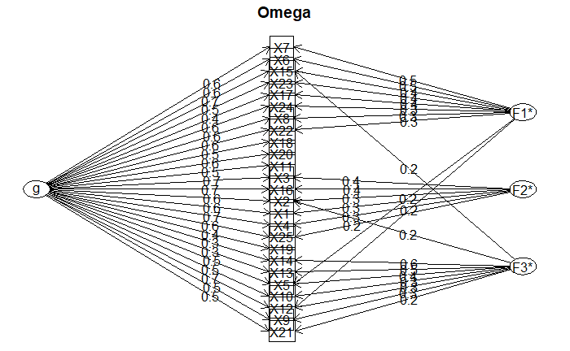

```r
#omega
psych::omega(data2_items)
```

```r
#inter-item correlation
data_correlation4 <- data2_items %>% corrr::correlate()
```

```
Correlation method: 'pearson'
Missing treated using: 'pairwise.complete.obs'
```

```r
data_correlation4 <- data_correlation4 %>% dplyr::select(-rowname) %>% colMeans(na.rm = TRUE)
data_correlation4
```

```
       X1        X2        X3        X4        X5        X6        X7        X8        X9       X10       X11
0.3800029 0.3606987 0.4003642 0.4433763 0.3893848 0.3746577 0.3787428 0.4143675 0.3347070 0.3342537 0.2970143
      X12       X13       X14       X15       X16       X17       X18       X19       X20       X21       X22
0.4623940 0.2339494 0.2394556 0.4657606 0.3976773 0.2677047 0.3527203 0.2713702 0.3836651 0.3203688 0.3879996
      X23       X24       X25
0.3712152 0.3966402 0.3946545
```

```r
mean(data_correlation4)
```

```
[1] 0.3621258
```

[figure not shown]

```r
data.frame(data_correlation4) %>%
  ggplot2::ggplot(aes(x = data_correlation4)) +
  geom_histogram(bins = 10, alpha = .5) +
  geom_vline(xintercept = mean(data_correlation4), color = "red") +
  xlab("Mean inter-item correlation") +
  theme_bw()
```

```r
data2_items$score<-rowSums(data2_items)
total_correlation3 <- data2_items %>% corrr::correlate() %>% focus(score)
```

```
Correlation method: 'pearson'
Missing treated using: 'pairwise.complete.obs'
```

```r
mean(total_correlation3$score)
```

```
[1] 0.6224598
```

Run an EFA and explore the best fit

```r
data2_items<- data2_items %>% dplyr::select(-'score')

psych::KMO(data2_items)
```

```
Kaiser-Meyer-Olkin factor adequacy
Call: psych::KMO(r = data2_items)
Overall MSA =  0.9
MSA for each item =
  X1   X2   X3   X4   X5   X6   X7   X8   X9  X10  X11  X12  X13  X14  X15  X16  X17  X18  X19  X20  X21  X22
0.92 0.93 0.91 0.93 0.89 0.91 0.88 0.88 0.86 0.91 0.90 0.93 0.76 0.82 0.93 0.88 0.87 0.90 0.85 0.92 0.88 0.83
 X23  X24  X25
0.92 0.95 0.91
```

```r
temp<-round(cor(data2_items),2)
cortest.bartlett(temp,n=nrow(data2_items))
```

```
$chisq
[1] 1463.155

$p.value
[1] 3.738487e-152

$df
[1] 300
```

```
Parallel analysis suggests that the number of factors =  2  and the number of components =  NA
```

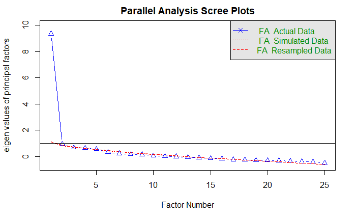

```r
parallel <- fa.parallel(data2_items, fm = 'minres', fa = 'fa')
```

```r
onefactor3 <- fa(data2_items,nfactors = 1,rotate = "oblimin",fm="minres")
print(onefactor3)
```

```
Factor Analysis using method =  minres
Call: fa(r = data2_items, nfactors = 1, rotate = "oblimin", fm = "minres")
Standardized loadings (pattern matrix) based upon correlation matrix
```

|  | MR1 | h2 | u2 | com |
| --- | --- | --- | --- | --- |
| X1 | 0.64 | 0.4079527 | 0.5920473 | 1 |
| X2 | 0.59 | 0.3507997 | 0.6492003 | 1 |
| X3 | 0.67 | 0.4501416 | 0.5498584 | 1 |
| X4 | 0.74 | 0.5495950 | 0.4504050 | 1 |
| X5 | 0.64 | 0.4121710 | 0.5878290 | 1 |
| X6 | 0.62 | 0.3899559 | 0.6100441 | 1 |
| X7 | 0.64 | 0.4047921 | 0.5952079 | 1 |
| X8 | 0.70 | 0.4836146 | 0.5163854 | 1 |
| X9 | 0.56 | 0.3117291 | 0.6882709 | 1 |
| X10 | 0.54 | 0.2939085 | 0.7060915 | 1 |

[output cut: 15 more lines]

```
                MR1
SS loadings    9.35
Proportion Var 0.37

Mean item complexity =  1
Test of the hypothesis that 1 factor is sufficient.

The degrees of freedom for the null model are  300  and the objective function was  13.68 with Chi Square of  1461.46
The degrees of freedom for the model are 275  and the objective function was  4.33

The root mean square of the residuals (RMSR) is  0.08
The df corrected root mean square of the residuals is  0.08

The harmonic number of observations is  117 with the empirical chi square  400.93  with prob <  1e-06
The total number of observations was  117  with Likelihood Chi Square =  459.43  with prob <  2e-11

Tucker Lewis Index of factoring reliability =  0.825
RMSEA index =  0.075  and the 90 % confidence intervals are  0.064 0.088
BIC =  -850.17
Fit based upon off diagonal values = 0.96
Measures of factor score adequacy
                                                   MR1
Correlation of (regression) scores with factors   0.97
Multiple R square of scores with factors          0.94
Minimum correlation of possible factor scores     0.89
```

Analyse data for canonical/shuffled separately

```r
data2_shuff<-data2[data2$version=='Shuffled_questionnaire',]
data2_shuff<-data2_shuff[,c('X1','X2','X3','X4','X5','X6','X7','X8','X9','X10','X11','X12','X13','X14','X15','X16','X17','X18','X19','X20','X21','X22','X23','X24','X25')]
data2_canon<-data2[data2$version=='Canonical_questionnaire',]
data2_canon<-data2_canon[,c('X1','X2','X3','X4','X5','X6','X7','X8','X9','X10','X11','X12','X13','X14','X15','X16','X17','X18','X19','X20','X21','X22','X23','X24','X25')]

psych::KMO(data2_canon)
```

```
Kaiser-Meyer-Olkin factor adequacy
Call: psych::KMO(r = data2_canon)
Overall MSA =  0.85
MSA for each item =
  X1   X2   X3   X4   X5   X6   X7   X8   X9  X10  X11  X12  X13  X14  X15  X16  X17  X18  X19  X20  X21  X22
0.89 0.87 0.89 0.82 0.80 0.85 0.78 0.90 0.73 0.82 0.86 0.92 0.78 0.77 0.90 0.89 0.75 0.86 0.77 0.85 0.77 0.85
 X23  X24  X25
0.91 0.94 0.89
```

```r
temp<-round(cor(data2_canon),2)
cortest.bartlett(temp,n=nrow(data2_canon))
```

```
$chisq
[1] 935.0534

$p.value
[1] 2.198422e-66

$df
[1] 300
```

```r
psych::KMO(data2_shuff)
```

```
Kaiser-Meyer-Olkin factor adequacy
Call: psych::KMO(r = data2_shuff)
Overall MSA =  0.81
MSA for each item =
  X1   X2   X3   X4   X5   X6   X7   X8   X9  X10  X11  X12  X13  X14  X15  X16  X17  X18  X19  X20  X21  X22
0.89 0.88 0.84 0.88 0.85 0.82 0.83 0.80 0.80 0.76 0.71 0.77 0.72 0.61 0.85 0.78 0.88 0.72 0.79 0.86 0.65 0.79
 X23  X24  X25
0.76 0.86 0.85
```

```r
temp<-round(cor(data2_shuff),2)
cortest.bartlett(temp,n=nrow(data2_shuff))
```

```
$chisq
[1] 775.7379

$p.value
[1] 7.822126e-44

$df
[1] 300
```

```
Parallel analysis suggests that the number of factors =  2  and the number of components =  NA
```

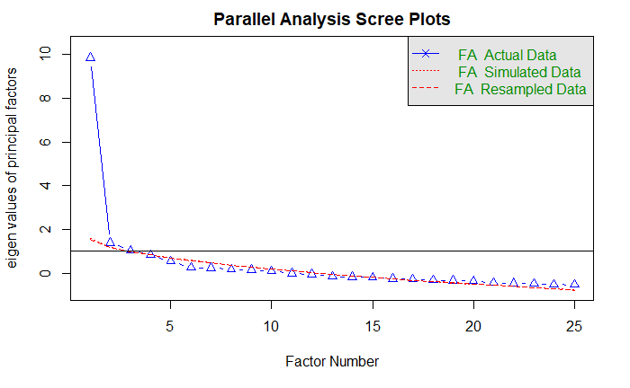

```r
parallel <- fa.parallel(data2_canon, fm = 'minres', fa = 'fa')
```

```r
onefactor<-fa(data2_canon,nfactors = 1,rotate = "oblimin",fm="minres")
twofactor<-fa(data2_canon,nfactors = 2,rotate = "oblimin",fm="minres")
print(onefactor)
```

```
Factor Analysis using method =  minres
Call: fa(r = data2_canon, nfactors = 1, rotate = "oblimin", fm = "minres")
Standardized loadings (pattern matrix) based upon correlation matrix
```

|  | MR1 | h2 | u2 | com |
| --- | --- | --- | --- | --- |
| X1 | 0.67 | 0.45001931 | 0.5499807 | 1 |
| X2 | 0.58 | 0.33605130 | 0.6639487 | 1 |
| X3 | 0.75 | 0.55665719 | 0.4433428 | 1 |
| X4 | 0.68 | 0.46585917 | 0.5341408 | 1 |
| X5 | 0.64 | 0.41565041 | 0.5843496 | 1 |
| X6 | 0.59 | 0.35002158 | 0.6499784 | 1 |
| X7 | 0.68 | 0.45888047 | 0.5411195 | 1 |
| X8 | 0.74 | 0.54392251 | 0.4560775 | 1 |
| X9 | 0.49 | 0.24187189 | 0.7581281 | 1 |
| X10 | 0.60 | 0.36507055 | 0.6349295 | 1 |

[output cut: 15 more lines]

```
                MR1
SS loadings    9.85
Proportion Var 0.39

Mean item complexity =  1
Test of the hypothesis that 1 factor is sufficient.

The degrees of freedom for the null model are  300  and the objective function was  17.93 with Chi Square of  929.57
The degrees of freedom for the model are 275  and the objective function was  7.59

The root mean square of the residuals (RMSR) is  0.1
The df corrected root mean square of the residuals is  0.1

The harmonic number of observations is  62 with the empirical chi square  369.38  with prob <  0.00012
The total number of observations was  62  with Likelihood Chi Square =  388.53  with prob <  7.5e-06

Tucker Lewis Index of factoring reliability =  0.799
RMSEA index =  0.08  and the 90 % confidence intervals are  0.062 0.101
BIC =  -746.43
Fit based upon off diagonal values = 0.94
Measures of factor score adequacy
                                                   MR1
Correlation of (regression) scores with factors   0.98
Multiple R square of scores with factors          0.95
Minimum correlation of possible factor scores     0.90
```

```r
print(twofactor)
```

```
Factor Analysis using method =  minres
Call: fa(r = data2_canon, nfactors = 2, rotate = "oblimin", fm = "minres")
Standardized loadings (pattern matrix) based upon correlation matrix
```

|  | MR1 | MR2 | h2 | u2 | com |
| --- | --- | --- | --- | --- | --- |
| X1 | 0.68 | 0.02 | 0.4678005 | 0.5321995 | 1.001542 |
| X2 | 0.33 | 0.41 | 0.3988012 | 0.6011988 | 1.913818 |
| X3 | 0.79 | -0.03 | 0.6002005 | 0.3997995 | 1.003891 |
| X4 | 0.53 | 0.26 | 0.4718622 | 0.5281378 | 1.470178 |
| X5 | 0.33 | 0.53 | 0.5364324 | 0.4635676 | 1.673656 |
| X6 | 0.70 | -0.14 | 0.4258899 | 0.5741101 | 1.083335 |
| X7 | 0.83 | -0.20 | 0.5830025 | 0.4169975 | 1.112882 |
| X8 | 0.67 | 0.14 | 0.5430628 | 0.4569372 | 1.081776 |
| X9 | 0.34 | 0.26 | 0.2576799 | 0.7423201 | 1.885202 |
| X10 | 0.38 | 0.38 | 0.4099609 | 0.5900391 | 1.999993 |

[output cut: 15 more lines]

```
                       MR1  MR2
SS loadings           8.58 2.87
Proportion Var        0.34 0.11
Cumulative Var        0.34 0.46
Proportion Explained  0.75 0.25
Cumulative Proportion 0.75 1.00

 With factor correlations of
     MR1  MR2
MR1 1.00 0.44
MR2 0.44 1.00

Mean item complexity =  1.3
Test of the hypothesis that 2 factors are sufficient.

The degrees of freedom for the null model are  300  and the objective function was  17.93 with Chi Square of  929.57
The degrees of freedom for the model are 251  and the objective function was  6.38

The root mean square of the residuals (RMSR) is  0.08
The df corrected root mean square of the residuals is  0.09

The harmonic number of observations is  62 with the empirical chi square  237.28  with prob <  0.72
The total number of observations was  62  with Likelihood Chi Square =  322.12  with prob <  0.0016

Tucker Lewis Index of factoring reliability =  0.86
RMSEA index =  0.066  and the 90 % confidence intervals are  0.044 0.089
BIC =  -713.79
Fit based upon off diagonal values = 0.96
Measures of factor score adequacy
                                                   MR1  MR2
Correlation of (regression) scores with factors   0.97 0.91
Multiple R square of scores with factors          0.95 0.83
Minimum correlation of possible factor scores     0.89 0.66
```

```
The estimated weights for the factor scores are probably incorrect.  Try a different factor score estimation method.
```

```
Parallel analysis suggests that the number of factors =  1  and the number of components =  NA
```

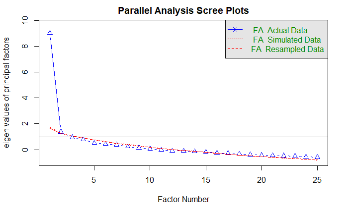

```r
parallel <- fa.parallel(data2_shuff, fm = 'minres', fa = 'fa')
```

```r
onefactor<-fa(data2_shuff,nfactors = 1,rotate = "oblimin",fm="minres")
print(onefactor)
```

```
Factor Analysis using method =  minres
Call: fa(r = data2_shuff, nfactors = 1, rotate = "oblimin", fm = "minres")
Standardized loadings (pattern matrix) based upon correlation matrix
```

|  | MR1 | h2 | u2 | com |
| --- | --- | --- | --- | --- |
| X1 | 0.59 | 0.3497079 | 0.6502921 | 1 |
| X2 | 0.60 | 0.3622146 | 0.6377854 | 1 |
| X3 | 0.57 | 0.3233283 | 0.6766717 | 1 |
| X4 | 0.82 | 0.6663486 | 0.3336514 | 1 |
| X5 | 0.65 | 0.4204227 | 0.5795773 | 1 |
| X6 | 0.67 | 0.4495529 | 0.5504471 | 1 |
| X7 | 0.58 | 0.3364212 | 0.6635788 | 1 |
| X8 | 0.64 | 0.4053658 | 0.5946342 | 1 |
| X9 | 0.64 | 0.4146651 | 0.5853349 | 1 |
| X10 | 0.45 | 0.2012296 | 0.7987704 | 1 |

[output cut: 15 more lines]

```
                MR1
SS loadings    9.03
Proportion Var 0.36

Mean item complexity =  1
Test of the hypothesis that 1 factor is sufficient.

The degrees of freedom for the null model are  300  and the objective function was  17.2 with Chi Square of  771.27
The degrees of freedom for the model are 275  and the objective function was  8.25

The root mean square of the residuals (RMSR) is  0.1
The df corrected root mean square of the residuals is  0.1

The harmonic number of observations is  55 with the empirical chi square  332.79  with prob <  0.0097
The total number of observations was  55  with Likelihood Chi Square =  364.39  with prob <  0.00024

Tucker Lewis Index of factoring reliability =  0.788
RMSEA index =  0.075  and the 90 % confidence intervals are  0.054 0.098
BIC =  -737.63
Fit based upon off diagonal values = 0.93
Measures of factor score adequacy
                                                   MR1
Correlation of (regression) scores with factors   0.97
Multiple R square of scores with factors          0.94
Minimum correlation of possible factor scores     0.89
```

t-tests for canonical/shuffled scores to check not different

```r
data2$score<-rowSums(select(data2,contains('X')))

t.test(data2$score[data2$version=='Canonical_questionnaire'],data2$score[data2$version=='Shuffled_questionnaire'])
```

```
    Welch Two Sample t-test

data:  data2$score[data2$version == "Canonical_questionnaire"] and data2$score[data2$version == "Shuffled_questionnaire"]
t = 0.80631, df = 114.79, p-value = 0.4217
alternative hypothesis: true difference in means is not equal to 0
95 percent confidence interval:
 -3.601572  8.546440
sample estimates:
mean of x mean of y
 65.14516  62.67273
```

```r
sd(data2$score[data2$version=='Canonical_questionnaire'])
```

```
[1] 17.22545
```

```r
sd(data2$score[data2$version=='Shuffled_questionnaire'])
```

```
[1] 15.93512
```

# Experiment 3

Load in the data

```r
data3<-read.csv(paste0(workingdir,'/experiment3.csv'))
```

Check how long the total experiment and questionnaire took

```r
cat_time_taken<-mean(data3$cat_questionnaire_time)
seconds_to_period(cat_time_taken/1000)
```

```
[1] "1M 59.380958S"
```

```r
short_time_taken<-mean(data3$short_questionnaire_time)
seconds_to_period(short_time_taken/1000)
```

```
[1] "26.457402S"
```

```r
full_time_taken<-mean(data3$total_time)
seconds_to_period(full_time_taken)
```

```
[1] "13M 53.053658S"
```

```r
data3_items<-select(data3,contains('cata')) #only the questionnaire items
```

Psychometric analyses of Catastrophising Questionnaire

```r
#alpha
psych::alpha(x=data3_items)
```

```
Reliability analysis
Call: psych::alpha(x = data3_items)
```

|  | raw_alpha | std.alpha | G6(smc) | average_r | S/N | ase | mean | sd | median_r |
| --- | --- | --- | --- | --- | --- | --- | --- | --- | --- |
|  | 0.9434497 | 0.9436893 | 0.9513245 | 0.4111675 | 16.75862 | 0.003623169 | 2.550417 | 0.7535934 | 0.4136128 |

```
 lower alpha upper     95% confidence boundaries
0.94 0.94 0.95

 Reliability if an item is dropped:
```

|  | raw_alpha | std.alpha | G6(smc) | average_r | S/N | alpha se | var.r | med.r |
| --- | --- | --- | --- | --- | --- | --- | --- | --- |
| cata1 | 0.9405198 | 0.9407394 | 0.9484845 | 0.4083544 | 15.87462 | 0.003814315 | 0.009501113 | 0.4095706 |
| cata2 | 0.9406488 | 0.9409097 | 0.9485060 | 0.4090937 | 15.92326 | 0.003806652 | 0.009297212 | 0.4127299 |
| cata3 | 0.9404297 | 0.9407341 | 0.9481624 | 0.4083313 | 15.87310 | 0.003822058 | 0.009016716 | 0.4115839 |
| cata4 | 0.9402146 | 0.9404786 | 0.9478273 | 0.4072268 | 15.80067 | 0.003834769 | 0.008923564 | 0.4095706 |
| cata5 | 0.9413102 | 0.9415851 | 0.9493352 | 0.4120490 | 16.11891 | 0.003762010 | 0.010005370 | 0.4156231 |
| cata6 | 0.9408240 | 0.9411075 | 0.9490225 | 0.4099553 | 15.98010 | 0.003796728 | 0.009598894 | 0.4126625 |
| cata7 | 0.9409719 | 0.9412216 | 0.9487785 | 0.4104536 | 16.01304 | 0.003786094 | 0.009704493 | 0.4134795 |
| cata8 | 0.9417612 | 0.9420080 | 0.9494883 | 0.4139197 | 16.24377 | 0.003731984 | 0.009936134 | 0.4173589 |
| cata9 | 0.9425666 | 0.9427469 | 0.9492957 | 0.4172241 | 16.46629 | 0.003676140 | 0.009211825 | 0.4184784 |
| cata10 | 0.9419368 | 0.9420658 | 0.9498628 | 0.4141762 | 16.26095 | 0.003723156 | 0.009700566 | 0.4168554 |

[output cut: 14 more lines]

```
 Item statistics
```

|  | n | raw.r | std.r | r.cor | r.drop | mean | sd |
| --- | --- | --- | --- | --- | --- | --- | --- |
| cata1 | 500 | 0.7039953 | 0.7050038 | 0.6928398 | 0.6720977 | 2.796 | 1.073634 |
| cata2 | 500 | 0.6935581 | 0.6931964 | 0.6811840 | 0.6598250 | 3.196 | 1.102731 |
| cata3 | 500 | 0.7082847 | 0.7053735 | 0.6960208 | 0.6728429 | 3.088 | 1.197968 |
| cata4 | 500 | 0.7231687 | 0.7230122 | 0.7164291 | 0.6909878 | 3.310 | 1.138636 |
| cata5 | 500 | 0.6474013 | 0.6459996 | 0.6259650 | 0.6081068 | 2.162 | 1.149957 |
| cata6 | 500 | 0.6823746 | 0.6794365 | 0.6625720 | 0.6444818 | 2.546 | 1.197812 |
| cata7 | 500 | 0.6748849 | 0.6714794 | 0.6558444 | 0.6348870 | 2.326 | 1.238868 |
| cata8 | 500 | 0.6147907 | 0.6161236 | 0.5944420 | 0.5734179 | 2.322 | 1.135295 |
| cata9 | 500 | 0.5617766 | 0.5633509 | 0.5443952 | 0.5149792 | 2.246 | 1.171422 |
| cata10 | 500 | 0.6174593 | 0.6120282 | 0.5878935 | 0.5708527 | 2.644 | 1.276135 |

[output cut: 14 more lines]

```
Non missing response frequency for each item
          1    2    3    4    5 miss
cata1  0.14 0.25 0.34 0.24 0.04    0
cata2  0.08 0.17 0.35 0.28 0.12    0
cata3  0.12 0.21 0.27 0.29 0.12    0
cata4  0.08 0.16 0.29 0.32 0.15    0
cata5  0.37 0.29 0.20 0.10 0.04    0
cata6  0.22 0.31 0.24 0.16 0.07    0
cata7  0.33 0.27 0.21 0.12 0.07    0
cata8  0.29 0.31 0.24 0.12 0.04    0
cata9  0.34 0.27 0.22 0.12 0.04    0
cata10 0.22 0.29 0.22 0.16 0.11    0
cata11 0.17 0.20 0.26 0.23 0.14    0
cata12 0.20 0.26 0.30 0.19 0.05    0
cata13 0.30 0.29 0.27 0.13 0.02    0
cata14 0.21 0.25 0.27 0.21 0.06    0
cata15 0.27 0.29 0.30 0.12 0.03    0
cata16 0.33 0.33 0.24 0.09 0.01    0
cata17 0.17 0.29 0.33 0.14 0.06    0
cata18 0.16 0.23 0.32 0.23 0.06    0
cata19 0.18 0.27 0.33 0.17 0.04    0
cata20 0.39 0.31 0.21 0.07 0.02    0
cata21 0.22 0.32 0.26 0.16 0.05    0
cata22 0.41 0.32 0.16 0.09 0.02    0
cata23 0.24 0.30 0.26 0.15 0.06    0
cata24 0.24 0.28 0.27 0.16 0.05    0
```

```
Omega
Call: omegah(m = m, nfactors = nfactors, fm = fm, key = key, flip = flip,
    digits = digits, title = title, sl = sl, labels = labels,
    plot = plot, n.obs = n.obs, rotate = rotate, Phi = Phi, option = option,
    covar = covar)
Alpha:                 0.94
G.6:                   0.95
Omega Hierarchical:    0.73
Omega H asymptotic:    0.76
Omega Total            0.95

Schmid Leiman Factor loadings greater than  0.2
```

|  | g | F1* | F2* | F3* | h2 | u2 | p2 |
| --- | --- | --- | --- | --- | --- | --- | --- |
| cata1 | 0.59 | 0.39 |  |  | 0.51 | 0.49 | 0.68 |
| cata2 | 0.57 | 0.44 |  |  | 0.53 | 0.47 | 0.61 |
| cata3 | 0.57 | 0.52 |  |  | 0.60 | 0.40 | 0.54 |
| cata4 | 0.59 | 0.49 |  |  | 0.60 | 0.40 | 0.59 |
| cata5 | 0.55 | 0.23 | 0.27 |  | 0.43 | 0.57 | 0.71 |
| cata6 | 0.56 | 0.37 |  |  | 0.46 | 0.54 | 0.70 |
| cata7 | 0.56 | 0.32 |  |  | 0.44 | 0.56 | 0.72 |
| cata8 | 0.53 |  | 0.22 |  | 0.38 | 0.62 | 0.75 |
| cata9 | 0.53 |  |  | 0.60 | 0.64 | 0.36 | 0.44 |
| cata10 | 0.50 | 0.33 |  |  | 0.36 | 0.64 | 0.69 |

[output cut: 14 more lines]

```
With eigenvalues of:
  g F1* F2* F3*
7.7 2.4 0.8 0.9

general/max  3.2   max/min =   3
mean percent general =  0.66    with sd =  0.1 and cv of  0.14
Explained Common Variance of the general factor =  0.65

The degrees of freedom are 207  and the fit is  1.06
The number of observations was  500  with Chi Square =  517.12  with prob <  1.7e-28
The root mean square of the residuals is  0.03
The df corrected root mean square of the residuals is  0.04
RMSEA index =  0.055  and the 10 % confidence intervals are  0.049 0.061
BIC =  -769.31

Compare this with the adequacy of just a general factor and no group factors
The degrees of freedom for just the general factor are 252  and the fit is  2.57
The number of observations was  500  with Chi Square =  1258.53  with prob <  2.4e-133
The root mean square of the residuals is  0.12
The df corrected root mean square of the residuals is  0.12

RMSEA index =  0.089  and the 10 % confidence intervals are  0.085 0.094
BIC =  -307.55

Measures of factor score adequacy
                                                 g   F1*  F2*  F3*
Correlation of scores with factors            0.86  0.68 0.71 0.73
Multiple R square of scores with factors      0.74  0.47 0.50 0.53
Minimum correlation of factor score estimates 0.47 -0.06 0.01 0.05

 Total, General and Subset omega for each subset
                                                 g  F1*  F2*  F3*
Omega total for total scores and subscales    0.95 0.93 0.71 0.79
Omega general for total scores and subscales  0.73 0.65 0.50 0.53
Omega group for total scores and subscales    0.15 0.28 0.22 0.26
```

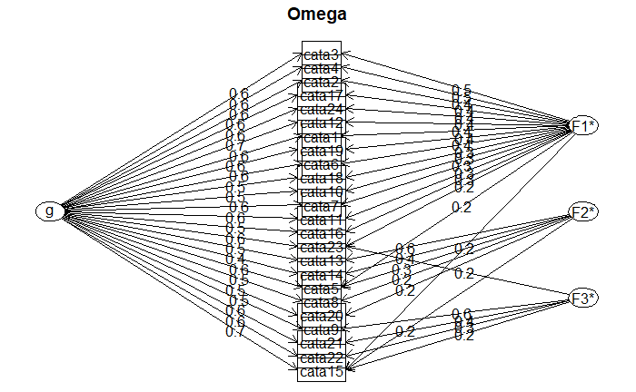

```r
#omega
psych::omega(data3_items)
```

```r
#inter-item correlation
data_correlation3 <- data3_items %>% corrr::correlate()
```

```
Correlation method: 'pearson'
Missing treated using: 'pairwise.complete.obs'
```

```r
data_correlation3 <- data_correlation3 %>% dplyr::select(-rowname) %>% colMeans(na.rm = TRUE)
data_correlation3
```

```
    cata1     cata2     cata3     cata4     cata5     cata6     cata7     cata8     cata9    cata10    cata11
0.4421117 0.4339791 0.4423664 0.4545155 0.4014711 0.4245016 0.4190210 0.3808932 0.3445445 0.3780724 0.4134037
   cata12    cata13    cata14    cata15    cata16    cata17    cata18    cata19    cata20    cata21    cata22
0.5175064 0.3130419 0.3069041 0.4800388 0.3790695 0.4368975 0.3752614 0.4685766 0.3422125 0.3839361 0.3784201
   cata23    cata24
0.4646716 0.4866038
```

```r
mean(data_correlation3)
```

```
[1] 0.4111675
```

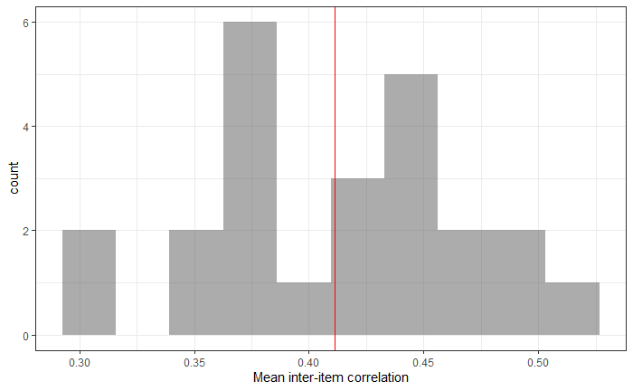

```r
data.frame(data_correlation3) %>%
  ggplot2::ggplot(aes(x = data_correlation3)) +
  geom_histogram(bins = 10, alpha = .5) +
  geom_vline(xintercept = mean(data_correlation3), color = "red") +
  xlab("Mean inter-item correlation") +
  theme_bw()
```

```r
#item-total correlation
data3_items$score<-rowSums(data3_items)
total_correlation3 <- data3_items %>% corrr::correlate() %>% focus(score)
```

```
Correlation method: 'pearson'
Missing treated using: 'pairwise.complete.obs'
```

```r
mean(total_correlation3$score)
```

```
[1] 0.6599983
```

Perform an EFA

```r
data3_items<- data3_items %>% dplyr::select(-'score') #remove the score column for now

psych::KMO(data3_items)
```

```
Kaiser-Meyer-Olkin factor adequacy
Call: psych::KMO(r = data3_items)
Overall MSA =  0.96
MSA for each item =
 cata1  cata2  cata3  cata4  cata5  cata6  cata7  cata8  cata9 cata10 cata11 cata12 cata13 cata14 cata15
  0.97   0.96   0.96   0.95   0.96   0.97   0.95   0.95   0.91   0.97   0.98   0.97   0.91   0.91   0.96
cata16 cata17 cata18 cata19 cata20 cata21 cata22 cata23 cata24
  0.97   0.96   0.96   0.97   0.97   0.93   0.94   0.98   0.96
```

```r
temp<-round(cor(data3_items),2)
cortest.bartlett(temp,n=nrow(data3_items))
```

```
$chisq
[1] 6182.794

$p.value
[1] 0

$df
[1] 276
```

```
Parallel analysis suggests that the number of factors =  4  and the number of components =  NA
```

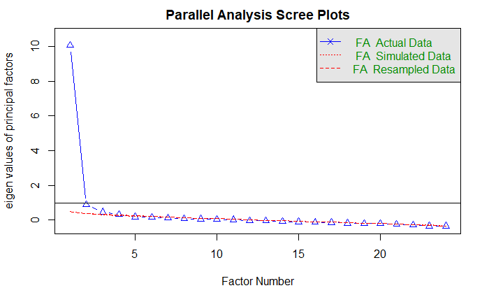

```r
parallel <- fa.parallel(data3_items, fm = 'minres', fa = 'fa')
```

```r
onefactor3 <- fa(data3_items,nfactors = 1,rotate = "oblimin",fm="minres")
print(onefactor3)
```

```
Factor Analysis using method =  minres
Call: fa(r = data3_items, nfactors = 1, rotate = "oblimin", fm = "minres")
Standardized loadings (pattern matrix) based upon correlation matrix
```

|  | MR1 | h2 | u2 | com |
| --- | --- | --- | --- | --- |
| cata1 | 0.69 | 0.4825701 | 0.5174299 | 1 |
| cata2 | 0.68 | 0.4687903 | 0.5312097 | 1 |
| cata3 | 0.70 | 0.4908301 | 0.5091699 | 1 |
| cata4 | 0.72 | 0.5191392 | 0.4808608 | 1 |
| cata5 | 0.62 | 0.3853834 | 0.6146166 | 1 |
| cata6 | 0.67 | 0.4456336 | 0.5543664 | 1 |
| cata7 | 0.66 | 0.4296190 | 0.5703810 | 1 |
| cata8 | 0.59 | 0.3431533 | 0.6568467 | 1 |
| cata9 | 0.52 | 0.2752589 | 0.7247411 | 1 |
| cata10 | 0.59 | 0.3479407 | 0.6520593 | 1 |

[output cut: 14 more lines]

```
                 MR1
SS loadings    10.07
Proportion Var  0.42

Mean item complexity =  1
Test of the hypothesis that 1 factor is sufficient.

The degrees of freedom for the null model are  276  and the objective function was  12.63 with Chi Square of  6190.94
The degrees of freedom for the model are 252  and the objective function was  2.07

The root mean square of the residuals (RMSR) is  0.06
The df corrected root mean square of the residuals is  0.06

The harmonic number of observations is  500 with the empirical chi square  867.39  with prob <  1.5e-68
The total number of observations was  500  with Likelihood Chi Square =  1013.26  with prob <  8.1e-92

Tucker Lewis Index of factoring reliability =  0.859
RMSEA index =  0.078  and the 90 % confidence intervals are  0.073 0.083
BIC =  -552.82
Fit based upon off diagonal values = 0.98
Measures of factor score adequacy
                                                   MR1
Correlation of (regression) scores with factors   0.97
Multiple R square of scores with factors          0.95
Minimum correlation of possible factor scores     0.90
```

Perform a CFA

```r
model<-' factor  =~ cata1 + cata2 + cata3 + cata4 + cata5 + cata6 + cata7 + cata8 + cata9 + cata10 + cata11 + cata12 + cata13 + cata14 + cata15 + cata16 + cata17 + cata18 + cata19 + cata20 + cata21 + cata22 + cata23 + cata24 '

fit<-lavaan::cfa(model=model,data=data3_items)
summary(fit, fit.measures=TRUE)
```

```
lavaan 0.6-5 ended normally after 24 iterations

  Estimator                                         ML
  Optimization method                           NLMINB
  Number of free parameters                         48

  Number of observations                           500

Model Test User Model:

  Test statistic                              1033.375
  Degrees of freedom                               252
  P-value (Chi-square)                           0.000

Model Test Baseline Model:

  Test statistic                              6315.134
  Degrees of freedom                               276
  P-value                                        0.000

User Model versus Baseline Model:

  Comparative Fit Index (CFI)                    0.871
  Tucker-Lewis Index (TLI)                       0.858

Loglikelihood and Information Criteria:

  Loglikelihood user model (H0)             -15932.470
  Loglikelihood unrestricted model (H1)     -15415.782

  Akaike (AIC)                               31960.940
  Bayesian (BIC)                             32163.241
  Sample-size adjusted Bayesian (BIC)        32010.886

Root Mean Square Error of Approximation:

  RMSEA                                          0.079
  90 Percent confidence interval - lower         0.074
  90 Percent confidence interval - upper         0.084
  P-value RMSEA <= 0.05                          0.000
```

[output cut: 51 more lines]

```
   .cata11            0.966    0.063   15.217    0.000
   .cata12            0.440    0.031   14.125    0.000
   .cata13            0.894    0.057   15.580    0.000
   .cata14            1.126    0.072   15.588    0.000
   .cata15            0.514    0.035   14.794    0.000
   .cata16            0.665    0.043   15.369    0.000
   .cata17            0.648    0.043   15.057    0.000
   .cata18            0.852    0.055   15.380    0.000
   .cata19            0.544    0.037   14.828    0.000
   .cata20            0.772    0.050   15.515    0.000
   .cata21            0.845    0.055   15.383    0.000
   .cata22            0.732    0.047   15.415    0.000
   .cata23            0.672    0.045   14.939    0.000
   .cata24            0.540    0.037   14.603    0.000
    factor            0.561    0.064    8.816    0.000
```

Check reliability of other questionnaires

```r
print('STAI')
```

```
[1] "STAI"
```

```
The estimated weights for the factor scores are probably incorrect.  Try a different factor score estimation method.An ultra-Heywood case was detected.  Examine the results carefullydiag(.) had 0 or NA entries; non-finite result is doubtful
```

```
Omega
Call: omegah(m = m, nfactors = nfactors, fm = fm, key = key, flip = flip,
    digits = digits, title = title, sl = sl, labels = labels,
    plot = plot, n.obs = n.obs, rotate = rotate, Phi = Phi, option = option,
    covar = covar)
Alpha:                 0.94
G.6:                   0.95
Omega Hierarchical:    0.78
Omega H asymptotic:    0.82
Omega Total            0.95

Schmid Leiman Factor loadings greater than  0.2
```

|  | g | F1* | F2* | F3* | h2 | u2 | p2 |
| --- | --- | --- | --- | --- | --- | --- | --- |
| stai_response.2.quantised | 0.76 |  |  |  | 0.59 | 0.41 | 0.97 |
| stai_response.3.quantised | 0.62 | 0.39 |  |  | 0.54 | 0.46 | 0.72 |
| stai_response.4.quantised | 0.81 |  |  | -0.20 | 0.70 | 0.30 | 0.93 |
| stai_response.5.quantised | 0.57 | 0.39 |  |  | 0.50 | 0.50 | 0.65 |
| stai_response.6.quantised | 0.64 | 0.41 |  | -0.27 | 0.64 | 0.36 | 0.63 |
| stai_response.7.quantised | 0.51 |  |  |  | 0.26 | 0.74 | 1.01 |
| stai_response.8.quantised | 0.67 |  |  |  | 0.51 | 0.49 | 0.90 |
| stai_response.9.quantised | 0.53 | 0.50 |  |  | 0.53 | 0.47 | 0.53 |
| stai_response.10.quantised | 0.44 | 0.54 |  | 0.21 | 0.55 | 0.45 | 0.36 |
| stai_response.11.quantised | 0.83 |  |  |  | 0.68 | 0.32 | 1.00 |

[output cut: 10 more lines]

```
With eigenvalues of:
   g  F1*  F2*  F3*
7.63 2.59 0.00 0.55

general/max  2.94   max/min =   Inf
mean percent general =  0.71    with sd =  0.24 and cv of  0.33
Explained Common Variance of the general factor =  0.71

The degrees of freedom are 133  and the fit is  0.62
The number of observations was  500  with Chi Square =  304.33  with prob <  1.9e-15
The root mean square of the residuals is  0.03
The df corrected root mean square of the residuals is  0.03
RMSEA index =  0.051  and the 10 % confidence intervals are  0.043 0.058
BIC =  -522.21

Compare this with the adequacy of just a general factor and no group factors
The degrees of freedom for just the general factor are 170  and the fit is  2.64
The number of observations was  500  with Chi Square =  1295.81  with prob <  2.1e-172
The root mean square of the residuals is  0.13
The df corrected root mean square of the residuals is  0.14

RMSEA index =  0.115  and the 10 % confidence intervals are  0.109 0.121
BIC =  239.33

Measures of factor score adequacy
                                                 g  F1* F2*  F3*
Correlation of scores with factors            0.96 0.90   0 0.75
Multiple R square of scores with factors      0.93 0.81   0 0.56
Minimum correlation of factor score estimates 0.85 0.62  -1 0.11

 Total, General and Subset omega for each subset
                                                 g  F1* F2*  F3*
Omega total for total scores and subscales    0.95 0.92  NA 0.91
Omega general for total scores and subscales  0.78 0.55  NA 0.91
Omega group for total scores and subscales    0.15 0.37  NA 0.01
```

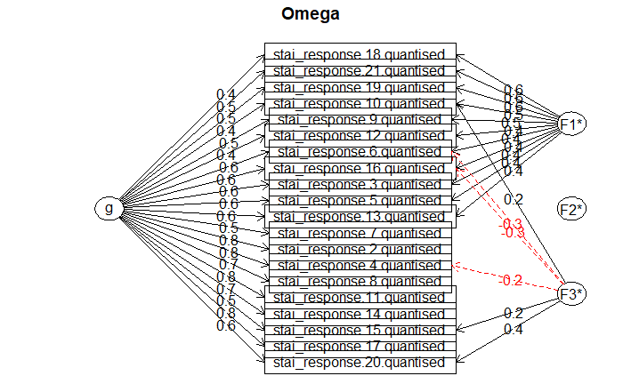

```r
psych::omega(select(data3,contains('STAI')))
```

```r
print('PHQ')
```

```
[1] "PHQ"
```

```
Omega
Call: omegah(m = m, nfactors = nfactors, fm = fm, key = key, flip = flip,
    digits = digits, title = title, sl = sl, labels = labels,
    plot = plot, n.obs = n.obs, rotate = rotate, Phi = Phi, option = option,
    covar = covar)
Alpha:                 0.89
G.6:                   0.88
Omega Hierarchical:    0.78
Omega H asymptotic:    0.86
Omega Total            0.91

Schmid Leiman Factor loadings greater than  0.2
```

|  | g | F1* | F2* | F3* | h2 | u2 | p2 |
| --- | --- | --- | --- | --- | --- | --- | --- |
| phq9_response.1.quantised | 0.69 |  | 0.23 |  | 0.56 | 0.44 | 0.87 |
| phq9_response.2.quantised | 0.84 |  | 0.39 |  | 0.85 | 0.15 | 0.82 |
| phq9_response.3.quantised | 0.58 | 0.44 |  |  | 0.54 | 0.46 | 0.63 |
| phq9_response.4.quantised | 0.59 | 0.54 |  |  | 0.64 | 0.36 | 0.54 |
| phq9_response.5.quantised | 0.59 | 0.37 |  |  | 0.50 | 0.50 | 0.70 |
| phq9_response.6.quantised | 0.73 |  |  |  | 0.61 | 0.39 | 0.88 |
| phq9_response.7.quantised | 0.67 |  |  | 0.36 | 0.59 | 0.41 | 0.75 |
| phq9_response.8.quantised | 0.56 |  |  | 0.36 | 0.45 | 0.55 | 0.70 |

```
With eigenvalues of:
   g  F1*  F2*  F3*
3.52 0.69 0.24 0.29

general/max  5.08   max/min =   2.84
mean percent general =  0.74    with sd =  0.12 and cv of  0.16
Explained Common Variance of the general factor =  0.74

The degrees of freedom are 7  and the fit is  0.03
The number of observations was  500  with Chi Square =  15.38  with prob <  0.031
The root mean square of the residuals is  0.01
The df corrected root mean square of the residuals is  0.03
RMSEA index =  0.049  and the 10 % confidence intervals are  0.014 0.082
BIC =  -28.12

Compare this with the adequacy of just a general factor and no group factors
The degrees of freedom for just the general factor are 20  and the fit is  0.36
The number of observations was  500  with Chi Square =  177.42  with prob <  3.1e-27
The root mean square of the residuals is  0.09
The df corrected root mean square of the residuals is  0.1

RMSEA index =  0.125  and the 10 % confidence intervals are  0.109 0.143
BIC =  53.12

Measures of factor score adequacy
                                                 g  F1*   F2*   F3*
Correlation of scores with factors            0.91 0.72  0.51  0.55
Multiple R square of scores with factors      0.82 0.51  0.26  0.30
Minimum correlation of factor score estimates 0.64 0.03 -0.47 -0.40

 Total, General and Subset omega for each subset
                                                 g  F1*  F2*  F3*
Omega total for total scores and subscales    0.91 0.79 0.84 0.68
Omega general for total scores and subscales  0.78 0.50 0.75 0.50
Omega group for total scores and subscales    0.08 0.29 0.09 0.17
```

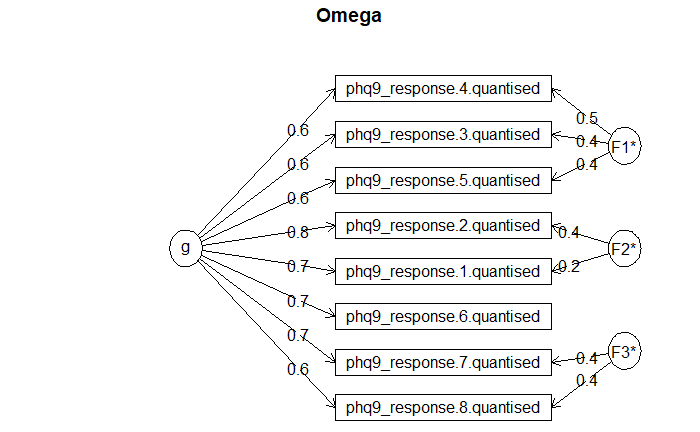

```r
psych::omega(select(data3,contains('PHQ')))
```

```r
print('GAD')
```

```
[1] "GAD"
```

```
Omega
Call: omegah(m = m, nfactors = nfactors, fm = fm, key = key, flip = flip,
    digits = digits, title = title, sl = sl, labels = labels,
    plot = plot, n.obs = n.obs, rotate = rotate, Phi = Phi, option = option,
    covar = covar)
Alpha:                 0.9
G.6:                   0.9
Omega Hierarchical:    0.75
Omega H asymptotic:    0.81
Omega Total            0.93

Schmid Leiman Factor loadings greater than  0.2
```

|  | g | F1* | F2* | F3* | h2 | u2 | p2 |
| --- | --- | --- | --- | --- | --- | --- | --- |
| gad7_response.1.quantised | 0.71 | 0.40 |  |  | 0.67 | 0.33 | 0.75 |
| gad7_response.2.quantised | 0.72 | 0.55 |  |  | 0.82 | 0.18 | 0.62 |
| gad7_response.3.quantised | 0.72 | 0.51 |  |  | 0.79 | 0.21 | 0.67 |
| gad7_response.4.quantised | 0.88 |  | 0.47 |  | 1.00 | 0.00 | 0.78 |
| gad7_response.5.quantised | 0.63 |  |  | 0.43 | 0.58 | 0.42 | 0.68 |
| gad7_response.6.quantised | 0.53 | 0.28 |  |  | 0.38 | 0.62 | 0.73 |
| gad7_response.7.quantised | 0.63 | 0.36 |  |  | 0.54 | 0.46 | 0.73 |

```
With eigenvalues of:
   g  F1*  F2*  F3*
3.38 0.94 0.23 0.24

general/max  3.6   max/min =   4.15
mean percent general =  0.71    with sd =  0.05 and cv of  0.08
Explained Common Variance of the general factor =  0.71

The degrees of freedom are 3  and the fit is  0.01
The number of observations was  500  with Chi Square =  7.19  with prob <  0.066
The root mean square of the residuals is  0.01
The df corrected root mean square of the residuals is  0.02
RMSEA index =  0.053  and the 10 % confidence intervals are  0 0.104
BIC =  -11.46

Compare this with the adequacy of just a general factor and no group factors
The degrees of freedom for just the general factor are 14  and the fit is  0.68
The number of observations was  500  with Chi Square =  337.17  with prob <  2e-63
The root mean square of the residuals is  0.13
The df corrected root mean square of the residuals is  0.16

RMSEA index =  0.215  and the 10 % confidence intervals are  0.196 0.235
BIC =  250.17

Measures of factor score adequacy
                                                 g  F1*   F2*   F3*
Correlation of scores with factors            0.92 0.77  0.68  0.57
Multiple R square of scores with factors      0.84 0.59  0.46  0.33
Minimum correlation of factor score estimates 0.69 0.19 -0.08 -0.35

 Total, General and Subset omega for each subset
                                                 g  F1*  F2*  F3*
Omega total for total scores and subscales    0.93 0.89 1.00 0.58
Omega general for total scores and subscales  0.75 0.63 0.78 0.40
Omega group for total scores and subscales    0.16 0.26 0.22 0.18
```

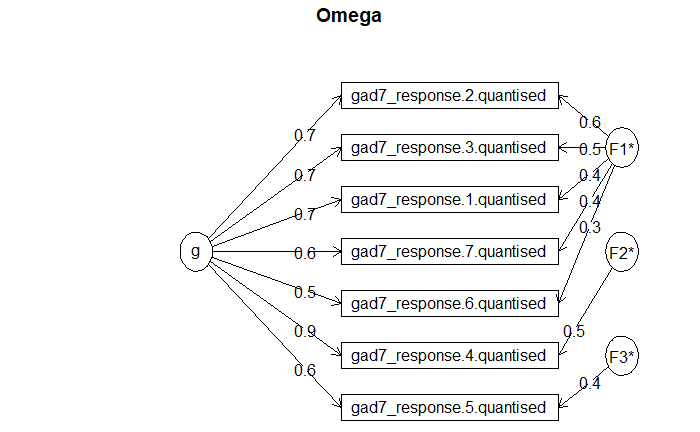

```r
psych::omega(select(data3,contains('GAD')))
```

```r
print('RRS')
```

```
[1] "RRS"
```

```
Omega
Call: omegah(m = m, nfactors = nfactors, fm = fm, key = key, flip = flip,
    digits = digits, title = title, sl = sl, labels = labels,
    plot = plot, n.obs = n.obs, rotate = rotate, Phi = Phi, option = option,
    covar = covar)
Alpha:                 0.95
G.6:                   0.95
Omega Hierarchical:    0.81
Omega H asymptotic:    0.84
Omega Total            0.95

Schmid Leiman Factor loadings greater than  0.2
```

|  | g | F1* | F2* | F3* | h2 | u2 | p2 |
| --- | --- | --- | --- | --- | --- | --- | --- |
| rrs_response.2.quantised | 0.66 |  | 0.24 |  | 0.53 | 0.47 | 0.82 |
| rrs_response.3.quantised | 0.64 | 0.25 |  |  | 0.49 | 0.51 | 0.84 |
| rrs_response.4.quantised | 0.59 | 0.30 |  |  | 0.43 | 0.57 | 0.79 |
| rrs_response.5.quantised | 0.60 | 0.28 |  |  | 0.44 | 0.56 | 0.81 |
| rrs_response.6.quantised | 0.58 |  | 0.43 |  | 0.52 | 0.48 | 0.64 |
| rrs_response.7.quantised | 0.67 | 0.44 |  |  | 0.65 | 0.35 | 0.70 |
| rrs_response.8.quantised | 0.61 |  |  | 0.30 | 0.49 | 0.51 | 0.75 |
| rrs_response.9.quantised | 0.62 |  |  |  | 0.45 | 0.55 | 0.83 |
| rrs_response.10.quantised | 0.69 | 0.35 |  |  | 0.61 | 0.39 | 0.79 |
| rrs_response.11.quantised | 0.63 |  |  |  | 0.47 | 0.53 | 0.85 |

[output cut: 12 more lines]

```
With eigenvalues of:
   g  F1*  F2*  F3*
8.51 1.10 0.86 1.04

general/max  7.73   max/min =   1.28
mean percent general =  0.73    with sd =  0.17 and cv of  0.23
Explained Common Variance of the general factor =  0.74

The degrees of freedom are 168  and the fit is  1.14
The number of observations was  500  with Chi Square =  559.29  with prob <  1.5e-43
The root mean square of the residuals is  0.03
The df corrected root mean square of the residuals is  0.04
RMSEA index =  0.068  and the 10 % confidence intervals are  0.062 0.075
BIC =  -484.77

Compare this with the adequacy of just a general factor and no group factors
The degrees of freedom for just the general factor are 209  and the fit is  2.24
The number of observations was  500  with Chi Square =  1096.34  with prob <  3.1e-120
The root mean square of the residuals is  0.09
The df corrected root mean square of the residuals is  0.09

RMSEA index =  0.092  and the 10 % confidence intervals are  0.087 0.098
BIC =  -202.52

Measures of factor score adequacy
                                                 g   F1*   F2*  F3*
Correlation of scores with factors            0.90  0.62  0.68 0.75
Multiple R square of scores with factors      0.81  0.38  0.46 0.56
Minimum correlation of factor score estimates 0.63 -0.24 -0.07 0.12

 Total, General and Subset omega for each subset
                                                 g  F1*  F2*  F3*
Omega total for total scores and subscales    0.95 0.90 0.85 0.78
Omega general for total scores and subscales  0.81 0.76 0.69 0.44
Omega group for total scores and subscales    0.08 0.15 0.16 0.34
```

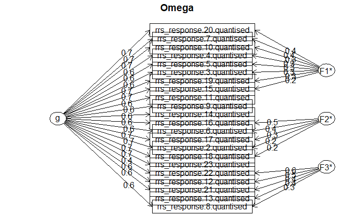

```r
psych::omega(select(data3,contains('RRS')))
```

```r
print('PSWQ')
```

```
[1] "PSWQ"
```

```
Omega
Call: omegah(m = m, nfactors = nfactors, fm = fm, key = key, flip = flip,
    digits = digits, title = title, sl = sl, labels = labels,
    plot = plot, n.obs = n.obs, rotate = rotate, Phi = Phi, option = option,
    covar = covar)
Alpha:                 0.94
G.6:                   0.95
Omega Hierarchical:    0.9
Omega H asymptotic:    0.94
Omega Total            0.95

Schmid Leiman Factor loadings greater than  0.2
```

|  | g | F1* | F2* | F3* | h2 | u2 | p2 |
| --- | --- | --- | --- | --- | --- | --- | --- |
| pswq_response.17.quantised | 0.40 |  | 0.36 |  | 0.32 | 0.68 | 0.51 |
| pswq_response.2.quantised | 0.79 |  |  |  | 0.65 | 0.35 | 0.96 |
| pswq_response.3.quantised | 0.62 |  | 0.48 |  | 0.61 | 0.39 | 0.63 |
| pswq_response.4.quantised | 0.83 |  |  |  | 0.72 | 0.28 | 0.95 |
| pswq_response.5.quantised | 0.79 |  |  |  | 0.64 | 0.36 | 0.97 |
| pswq_response.6.quantised | 0.73 |  |  |  | 0.58 | 0.42 | 0.93 |
| pswq_response.7.quantised | 0.83 |  |  |  | 0.70 | 0.30 | 0.99 |
| pswq_response.8.quantised | 0.47 |  | 0.43 |  | 0.42 | 0.58 | 0.53 |
| pswq_response.9.quantised | 0.69 |  |  | 0.22 | 0.53 | 0.47 | 0.90 |
| pswq_response.10.quantised | 0.60 |  | 0.46 |  | 0.57 | 0.43 | 0.62 |

[output cut: 6 more lines]

```
With eigenvalues of:
   g  F1*  F2*  F3*
8.09 0.01 1.01 0.29

general/max  7.97   max/min =   172.68
mean percent general =  0.83    with sd =  0.19 and cv of  0.23
Explained Common Variance of the general factor =  0.86

The degrees of freedom are 75  and the fit is  0.32
The number of observations was  500  with Chi Square =  158.43  with prob <  6.5e-08
The root mean square of the residuals is  0.02
The df corrected root mean square of the residuals is  0.02
RMSEA index =  0.047  and the 10 % confidence intervals are  0.037 0.057
BIC =  -307.66

Compare this with the adequacy of just a general factor and no group factors
The degrees of freedom for just the general factor are 104  and the fit is  0.93
The number of observations was  500  with Chi Square =  458.74  with prob <  4.9e-46
The root mean square of the residuals is  0.06
The df corrected root mean square of the residuals is  0.07

RMSEA index =  0.083  and the 10 % confidence intervals are  0.075 0.09
BIC =  -187.58

Measures of factor score adequacy
                                                 g   F1*  F2*   F3*
Correlation of scores with factors            0.97  0.04 0.79  0.63
Multiple R square of scores with factors      0.95  0.00 0.62  0.40
Minimum correlation of factor score estimates 0.90 -1.00 0.25 -0.20

 Total, General and Subset omega for each subset
                                                 g F1*  F2*  F3*
Omega total for total scores and subscales    0.95  NA 0.92 0.90
Omega general for total scores and subscales  0.90  NA 0.79 0.89
Omega group for total scores and subscales    0.05  NA 0.13 0.01
```

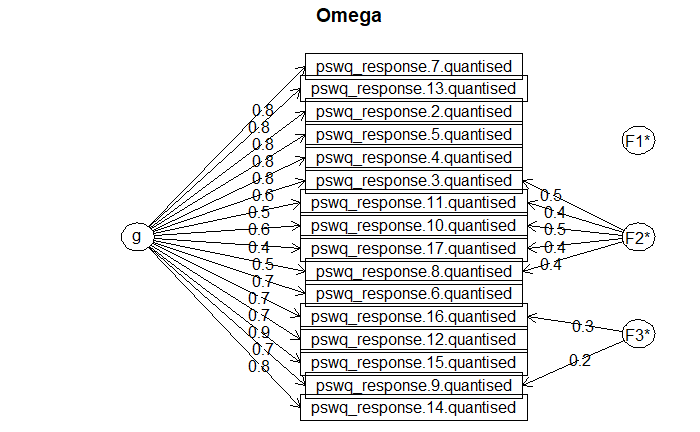

```r
psych::omega(select(data3,contains('PSWQ')))
```

```r
print('TEPS-ANT')
```

```
[1] "TEPS-ANT"
```

```
Omega
Call: omegah(m = m, nfactors = nfactors, fm = fm, key = key, flip = flip,
    digits = digits, title = title, sl = sl, labels = labels,
    plot = plot, n.obs = n.obs, rotate = rotate, Phi = Phi, option = option,
    covar = covar)
Alpha:                 0.77
G.6:                   0.78
Omega Hierarchical:    0.6
Omega H asymptotic:    0.73
Omega Total            0.82

Schmid Leiman Factor loadings greater than  0.2
```

|  | g | F1* | F2* | F3* | h2 | u2 | p2 |
| --- | --- | --- | --- | --- | --- | --- | --- |
| teps_ant_response.11.quantised | 0.46 |  |  | 0.52 | 0.49 | 0.51 | 0.43 |
| teps_ant_response.12.quantised | 0.29 |  |  | 0.30 | 0.21 | 0.79 | 0.42 |
| teps_ant_response.14.quantised | 0.26 | 0.21 |  |  | 0.11 | 0.89 | 0.59 |
| teps_ant_response.16.quantised | 0.54 |  | 0.58 |  | 0.63 | 0.37 | 0.46 |
| teps_ant_response.17.quantised | 0.61 |  | 0.55 |  | 0.68 | 0.32 | 0.54 |
| teps_ant_response.19.quantised | 0.61 | 0.49 |  |  | 0.61 | 0.39 | 0.60 |
| teps_ant_response.2.quantised | 0.31 |  |  | 0.27 | 0.19 | 0.81 | 0.52 |
| teps_ant_response.5.quantised | 0.50 | 0.35 |  |  | 0.39 | 0.61 | 0.66 |
| teps_ant_response.7.quantised | 0.54 | 0.38 |  |  | 0.44 | 0.56 | 0.66 |
| teps_ant_response.9.quantised | 0.29 |  | 0.24 | 0.33 | 0.27 | 0.73 | 0.32 |

```
With eigenvalues of:
   g  F1*  F2*  F3*
2.13 0.60 0.74 0.55

general/max  2.88   max/min =   1.35
mean percent general =  0.52    with sd =  0.11 and cv of  0.22
Explained Common Variance of the general factor =  0.53

The degrees of freedom are 18  and the fit is  0.08
The number of observations was  500  with Chi Square =  37.42  with prob <  0.0046
The root mean square of the residuals is  0.02
The df corrected root mean square of the residuals is  0.04
RMSEA index =  0.046  and the 10 % confidence intervals are  0.025 0.068
BIC =  -74.44

Compare this with the adequacy of just a general factor and no group factors
The degrees of freedom for just the general factor are 35  and the fit is  0.59
The number of observations was  500  with Chi Square =  292.81  with prob <  1.9e-42
The root mean square of the residuals is  0.1
The df corrected root mean square of the residuals is  0.11

RMSEA index =  0.121  and the 10 % confidence intervals are  0.109 0.135
BIC =  75.3

Measures of factor score adequacy
                                                 g   F1*  F2*   F3*
Correlation of scores with factors            0.80  0.61 0.71  0.64
Multiple R square of scores with factors      0.63  0.37 0.50  0.41
Minimum correlation of factor score estimates 0.27 -0.26 0.01 -0.18

 Total, General and Subset omega for each subset
                                                 g  F1*  F2*  F3*
Omega total for total scores and subscales    0.82 0.70 0.79 0.57
Omega general for total scores and subscales  0.60 0.45 0.40 0.28
Omega group for total scores and subscales    0.16 0.25 0.39 0.29
```

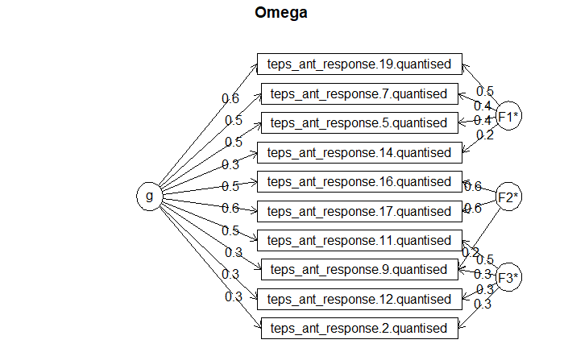

```r
psych::omega(select(data3,contains('teps_ant')))
```

```r
print('TEPS-CON')
```

```
[1] "TEPS-CON"
```

```
Omega
Call: omegah(m = m, nfactors = nfactors, fm = fm, key = key, flip = flip,
    digits = digits, title = title, sl = sl, labels = labels,
    plot = plot, n.obs = n.obs, rotate = rotate, Phi = Phi, option = option,
    covar = covar)
Alpha:                 0.68
G.6:                   0.68
Omega Hierarchical:    0.58
Omega H asymptotic:    0.76
Omega Total            0.77

Schmid Leiman Factor loadings greater than  0.2
```

|  | g | F1* | F2* | F3* | h2 | u2 | p2 |
| --- | --- | --- | --- | --- | --- | --- | --- |
| teps_con_response.10.quantised | 0.50 |  |  |  | 0.31 | 0.69 | 0.80 |
| teps_con_response.13.quantised | 0.30 |  |  |  | 0.12 | 0.88 | 0.77 |
| teps_con_response.15.quantised | 0.42 |  |  | 0.75 | 0.75 | 0.25 | 0.24 |
| teps_con_response.18.quantised | 0.51 |  |  | 0.27 | 0.36 | 0.64 | 0.72 |
| teps_con_response.3.quantised | 0.62 | 0.28 |  |  | 0.47 | 0.53 | 0.83 |
| teps_con_response.4.quantised | 0.55 | 0.28 |  |  | 0.39 | 0.61 | 0.78 |
| teps_con_response.6.quantised |  |  |  |  | 0.02 | 0.98 | 0.65 |
| teps_con_response.8.quantised | 0.39 |  | 0.92 |  | 1.00 | 0.00 | 0.15 |

```
With eigenvalues of:
   g  F1*  F2*  F3*
1.63 0.23 0.86 0.67

general/max  1.89   max/min =   3.71
mean percent general =  0.62    with sd =  0.27 and cv of  0.43
Explained Common Variance of the general factor =  0.48

The degrees of freedom are 7  and the fit is  0.02
The number of observations was  500  with Chi Square =  9.24  with prob <  0.24
The root mean square of the residuals is  0.02
The df corrected root mean square of the residuals is  0.04
RMSEA index =  0.025  and the 10 % confidence intervals are  0 0.064
BIC =  -34.26

Compare this with the adequacy of just a general factor and no group factors
The degrees of freedom for just the general factor are 20  and the fit is  0.14
The number of observations was  500  with Chi Square =  69.66  with prob <  2.1e-07
The root mean square of the residuals is  0.06
The df corrected root mean square of the residuals is  0.07

RMSEA index =  0.07  and the 10 % confidence intervals are  0.053 0.089
BIC =  -54.63

Measures of factor score adequacy
                                                 g   F1*  F2*  F3*
Correlation of scores with factors            0.80  0.38 0.96 0.80
Multiple R square of scores with factors      0.63  0.14 0.93 0.64
Minimum correlation of factor score estimates 0.27 -0.71 0.86 0.27

 Total, General and Subset omega for each subset
                                                 g  F1*  F2*  F3*
Omega total for total scores and subscales    0.77 0.63 1.00 0.54
Omega general for total scores and subscales  0.58 0.53 0.15 0.26
Omega group for total scores and subscales    0.14 0.10 0.84 0.28
```

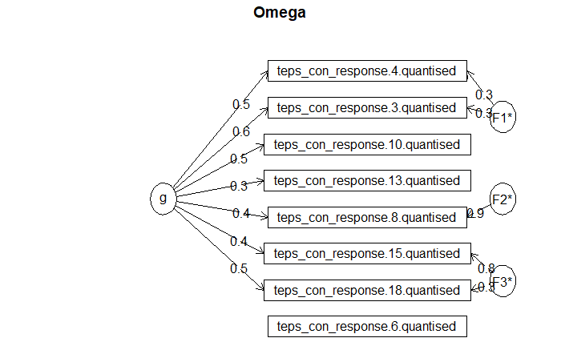

```r
psych::omega(select(data3,contains('teps_con')))
```

```r
print('CDS')
```

```
[1] "CDS"
```

```r
psych::alpha(select(data3,contains('cds')))
```

```
data length [16] is not a sub-multiple or multiple of the number of columns [10]
```

```
Reliability analysis
Call: psych::alpha(x = select(data3, contains("cds")))
```

|  | raw_alpha | std.alpha | G6(smc) | average_r | S/N | ase | mean | sd | median_r |
| --- | --- | --- | --- | --- | --- | --- | --- | --- | --- |
|  | 0.7003971 | 0.7004679 | 0.5390154 | 0.5390154 | 2.33854 | 0.02679142 | 4.188 | 1.432047 | 0.5390154 |

```
 lower alpha upper     95% confidence boundaries
0.65 0.7 0.75

 Reliability if an item is dropped:
```

|  | raw_alpha | std.alpha | G6(smc) | average_r | S/N | alpha se | var.r | med.r |
| --- | --- | --- | --- | --- | --- | --- | --- | --- |
| cds_cat_social | 0.5390154 | 0.5390154 | 0.2905377 | 0.5390154 | NA | NA | 0.5390154 | 0.5390154 |
| cds_cat_achievement | 0.2905377 | 0.5390154 | NA | NA | NA | NA | 0.2905377 | 0.5390154 |

```
 Item statistics
```

|  | n | raw.r | std.r | r.cor | r.drop | mean | sd |
| --- | --- | --- | --- | --- | --- | --- | --- |
| cds_cat_social | 500 | 0.8748892 | 0.8772159 | 0.6440315 | 0.5390154 | 4.084 | 1.618079 |
| cds_cat_achievement | 500 | 0.8795222 | 0.8772159 | 0.6440315 | 0.5390154 | 4.292 | 1.646864 |

```
Non missing response frequency for each item
                       1    2    3    4    5    6    7 miss
cds_cat_social      0.04 0.17 0.18 0.17 0.22 0.16 0.06    0
cds_cat_achievement 0.05 0.12 0.16 0.20 0.20 0.20 0.08    0
```

```r
print('Short')
```

```
[1] "Short"
```

```
Omega
Call: omegah(m = m, nfactors = nfactors, fm = fm, key = key, flip = flip,
    digits = digits, title = title, sl = sl, labels = labels,
    plot = plot, n.obs = n.obs, rotate = rotate, Phi = Phi, option = option,
    covar = covar)
Alpha:                 0.81
G.6:                   0.77
Omega Hierarchical:    0.79
Omega H asymptotic:    0.96
Omega Total            0.83

Schmid Leiman Factor loadings greater than  0.2
```

|  | g | F1* | F2* | F3* | h2 | u2 | p2 |
| --- | --- | --- | --- | --- | --- | --- | --- |
| short_X1.quantised | 0.72 |  |  |  | 0.54 | 0.46 | 0.97 |
| short_X2.quantised | 0.75 |  |  |  | 0.57 | 0.43 | 0.99 |
| short_X3.quantised | 0.63 | 0.27 |  |  | 0.49 | 0.51 | 0.81 |
| short_X4.quantised | 0.74 | 0.31 |  |  | 0.65 | 0.35 | 0.85 |

```
With eigenvalues of:
   g  F1*  F2*  F3*
2.04 0.17 0.00 0.04

general/max  11.99   max/min =   87.9
mean percent general =  0.9    with sd =  0.09 and cv of  0.1
Explained Common Variance of the general factor =  0.91

The degrees of freedom are -3  and the fit is  0
The number of observations was  500  with Chi Square =  0  with prob <  NA
The root mean square of the residuals is  0
The df corrected root mean square of the residuals is  NA

Compare this with the adequacy of just a general factor and no group factors
The degrees of freedom for just the general factor are 2  and the fit is  0.02
The number of observations was  500  with Chi Square =  8.65  with prob <  0.013
The root mean square of the residuals is  0.03
The df corrected root mean square of the residuals is  0.06

RMSEA index =  0.082  and the 10 % confidence intervals are  0.032 0.141
BIC =  -3.78

Measures of factor score adequacy
                                                 g   F1*   F2*   F3*
Correlation of scores with factors            0.90  0.44  0.05  0.27
Multiple R square of scores with factors      0.80  0.20  0.00  0.07
Minimum correlation of factor score estimates 0.61 -0.61 -1.00 -0.85

 Total, General and Subset omega for each subset
                                                 g  F1* F2*  F3*
Omega total for total scores and subscales    0.83 0.72  NA 0.71
Omega general for total scores and subscales  0.79 0.61  NA 0.71
Omega group for total scores and subscales    0.03 0.11  NA 0.00
```

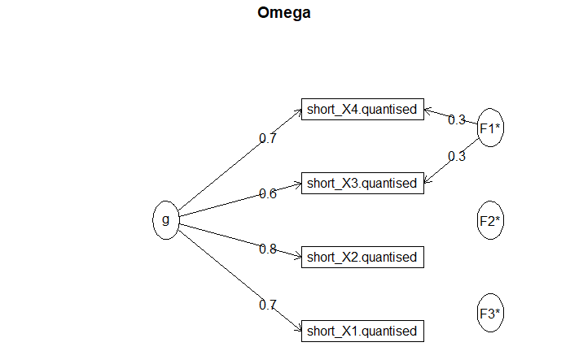

```r
psych::omega(select(data3,c(contains('short_X')))) #the extra bit is needed so don't get the time
```

Now, perform an FA on all questionnaires together (excluding the short version of the Catastrophising Questionnaire)

```
Parallel analysis suggests that the number of factors =  9  and the number of components =  NA
```

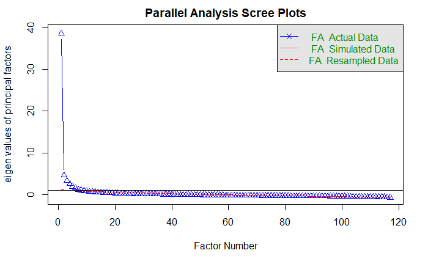

```r
data3_fa<-select(data3,-c(contains('short'),contains('time'),contains('id'),contains('medication'),contains('diagnosis')))

data3_fa<-data3_fa[,order(colnames(data3_fa))] #put in alphabetical order to replicate graph exactly

parallel <- fa.parallel(data3_fa, fm = 'minres', fa = 'fa')
```

```r
fit<-fa(data3_fa,nfactors=9)
fit
```

```
Factor Analysis using method =  minres
Call: fa(r = data3_fa, nfactors = 9)
Standardized loadings (pattern matrix) based upon correlation matrix
```

|  | MR1 | MR4 | MR3 | MR5 | MR8 | MR2 | MR7 | MR6 | MR9 | h2 | u2 | com |
| --- | --- | --- | --- | --- | --- | --- | --- | --- | --- | --- | --- | --- |
| cata1 | 0.28 | 0.30 | 0.03 | -0.01 | 0.02 | 0.06 | -0.08 | 0.21 | 0.06 | 0.4994049 | 0.5005951 | 3.189088 |
| cata10 | 0.16 | 0.31 | 0.02 | 0.03 | -0.12 | 0.07 | -0.15 | 0.17 | 0.16 | 0.3863885 | 0.6136115 | 3.887757 |
| cata11 | -0.05 | 0.36 | -0.04 | 0.17 | 0.11 | 0.02 | 0.05 | 0.30 | 0.13 | 0.4874837 | 0.5125163 | 3.094597 |
| cata12 | 0.15 | 0.48 | 0.08 | 0.01 | 0.12 | -0.01 | -0.06 | 0.19 | 0.05 | 0.6604375 | 0.3395625 | 1.789519 |
| cata13 | -0.09 | 0.55 | 0.05 | 0.14 | -0.05 | -0.07 | 0.05 | -0.02 | 0.01 | 0.3219354 | 0.6780646 | 1.283380 |
| cata14 | -0.06 | 0.47 | 0.10 | 0.06 | -0.04 | -0.08 | 0.08 | 0.06 | 0.08 | 0.2805166 | 0.7194834 | 1.407953 |
| cata15 | 0.03 | 0.64 | 0.09 | 0.00 | 0.10 | 0.04 | -0.06 | 0.00 | 0.00 | 0.5981522 | 0.4018478 | 1.120520 |
| cata16 | 0.03 | 0.35 | 0.12 | 0.01 | 0.14 | 0.18 | -0.11 | 0.14 | -0.17 | 0.4153110 | 0.5846890 | 3.463478 |
| cata17 | 0.18 | 0.29 | -0.01 | 0.00 | 0.17 | -0.02 | -0.01 | 0.29 | 0.11 | 0.5124493 | 0.4875507 | 3.592708 |
| cata18 | 0.17 | 0.24 | -0.01 | -0.01 | 0.11 | 0.19 | -0.09 | 0.25 | -0.03 | 0.4108592 | 0.5891408 | 4.379321 |

[output cut: 107 more lines]

```
                        MR1  MR4  MR3  MR5  MR8  MR2  MR7  MR6  MR9
SS loadings           12.31 8.72 7.78 7.81 6.82 3.01 3.39 4.17 3.17
Proportion Var         0.11 0.07 0.07 0.07 0.06 0.03 0.03 0.04 0.03
Cumulative Var         0.11 0.18 0.25 0.31 0.37 0.40 0.43 0.46 0.49
Proportion Explained   0.22 0.15 0.14 0.14 0.12 0.05 0.06 0.07 0.06
Cumulative Proportion  0.22 0.37 0.50 0.64 0.76 0.81 0.87 0.94 1.00

 With factor correlations of
      MR1   MR4   MR3   MR5   MR8   MR2   MR7   MR6   MR9
MR1  1.00  0.50  0.37  0.46  0.41  0.26 -0.20  0.34  0.28
MR4  0.50  1.00  0.43  0.46  0.36  0.12 -0.32  0.35  0.24
MR3  0.37  0.43  1.00  0.44  0.33  0.10 -0.18  0.35  0.29
MR5  0.46  0.46  0.44  1.00  0.41  0.07 -0.20  0.28  0.28
MR8  0.41  0.36  0.33  0.41  1.00 -0.05 -0.34  0.26  0.29
MR2  0.26  0.12  0.10  0.07 -0.05  1.00  0.17  0.15  0.10
MR7 -0.20 -0.32 -0.18 -0.20 -0.34  0.17  1.00 -0.16 -0.07
MR6  0.34  0.35  0.35  0.28  0.26  0.15 -0.16  1.00  0.22
MR9  0.28  0.24  0.29  0.28  0.29  0.10 -0.07  0.22  1.00

Mean item complexity =  2.3
Test of the hypothesis that 9 factors are sufficient.

The degrees of freedom for the null model are  6786  and the objective function was  84.42 with Chi Square of  38760.93
The degrees of freedom for the model are 5769  and the objective function was  19.66

The root mean square of the residuals (RMSR) is  0.03
The df corrected root mean square of the residuals is  0.03

The harmonic number of observations is  500 with the empirical chi square  4979.05  with prob <  1
The total number of observations was  500  with Likelihood Chi Square =  8908.95  with prob <  4.8e-140

Tucker Lewis Index of factoring reliability =  0.883
RMSEA index =  0.033  and the 90 % confidence intervals are  0.032 0.034
BIC =  -26943.12
Fit based upon off diagonal values = 0.99
Measures of factor score adequacy
                                                   MR1  MR4  MR3  MR5  MR8  MR2  MR7  MR6  MR9
Correlation of (regression) scores with factors   0.98 0.95 0.95 0.96 0.95 0.91 0.90 0.90 0.89
Multiple R square of scores with factors          0.95 0.91 0.91 0.91 0.91 0.82 0.81 0.81 0.80
Minimum correlation of possible factor scores     0.90 0.82 0.81 0.83 0.81 0.65 0.63 0.63 0.60
```

```r
loadings<-data.frame(fit$loadings[])

colnames(loadings)<-c("worry", "catastrophizing","rumination", "low mood and anxiety", "trait anxiety", "anticipatory anhedonia", "consummatory anhedonia", "other1", "other2")

names<-c(rep('Catastrophising',24),rep('CDS-CAT',2),rep('GAD-7',7),rep('PHQ-9',8),rep('PSWQ',16),rep('RRS',22),c(rep('STAI-T',20),rep('TEPS-ANT',10),rep('TEPS-CON',8)))

names_df<-data.frame(Questionnaire=names)
rownames(names_df) <- rownames(loadings)

ancol<- list(Questionnaire =c('Catastrophising' ="lavenderblush4", 'GAD-7' ="plum3",'PHQ-9' ="goldenrod1", 'PSWQ'="darkorange4", 'RRS'='firebrick3', 'STAI-T'='darkseagreen1', 'TEPS-ANT'="darksalmon",'TEPS-CON'="darkslateblue",'CDS-CAT' ="darkolivegreen3"))
```

Generate figure 1a (heatmap of factor analysis of all convergent/divergent measures)

[figure not shown]

```r
heatmapplot <- pheatmap(
  mat               = loadings,
  border_color      = NA,
  color             = colorRampPalette(c("blue4", "white", "firebrick1"))(100),
  cellwidth         = 70,
  cellheight        = 3,
  show_colnames     = TRUE,
  show_rownames     = FALSE,
  drop_levels       = TRUE,
  fontsize          = 14,
  main              = "Factors",
  treeheight_row    = 0,
  treeheight_col    = 0,
  cluster_rows      = FALSE,
  annotation_row    = names_df,
  annotation_colors = ancol,
  angle_col         = 45,
  gaps_col          = c(1,2),
  width             = 5,
  height            = 5
)
```

```r
if (save_images==1){
  ggsave(heatmapplot,filename=paste0(workingdir,'/fa_heatmap.png'),width=12,height=9)
}
```

Generate figure 1b (heatmap of correlations between all questionnaires)

```r
Cat<-rowSums(select(data3,contains('cata')))
scores<-data.frame(Cat)
scores$STAI<-rowSums(select(data3,contains('STAI')))
scores$PHQ<-rowSums(select(data3,contains('PHQ')))
scores$GAD<-rowSums(select(data3,contains('GAD')))
scores$RRS<-rowSums(select(data3,contains('RRS')))
scores$PSWQ<-rowSums(select(data3,contains('PSWQ')))
scores$TEPS_ANT<-rowSums(select(data3,contains('teps_ant')))
scores$TEPS_CON<-rowSums(select(data3,contains('teps_con')))
scores$CDS<-rowSums(select(data3,contains('cds')))
scores$short_cat<-rowSums(select(data3,c(contains('short_X')))) #the extra bit is needed so don't get the time

cormat <- round(cor(scores),2)
melted_cormat <- melt(cormat)
melted_cormat$Var1<-factor(melted_cormat$Var1,ordered=TRUE,levels=c('Cat','short_cat','CDS','GAD','PHQ','PSWQ','RRS','STAI','TEPS_ANT','TEPS_CON'))
melted_cormat$Var2<-factor(melted_cormat$Var2,ordered=TRUE,levels=c('Cat','short_cat','CDS','GAD','PHQ','PSWQ','RRS','STAI','TEPS_ANT','TEPS_CON'))

corrplot<-ggplot(data = melted_cormat, aes(x=Var2, y=Var1, fill=value)) +
  geom_tile()+
  scale_fill_gradient2(midpoint = 0, low = "navy", mid = "white", high = "red")+
  geom_text(aes(Var2, Var1, label = value), color = "black", size = 4)

if (save_images==1){
  ggsave(corrplot,filename=paste0(workingdir,'/questionnaire_correlations.png'),width=12,height=9)
}
```

Simple correlations between Catastrophising questionnaire and convergent/divergent validity measures, along with p values

```r
cor.test(scores$Cat,scores$short_cat)
```

```
    Pearson's product-moment correlation

data:  scores$Cat and scores$short_cat
t = 30.496, df = 498, p-value < 2.2e-16
alternative hypothesis: true correlation is not equal to 0
95 percent confidence interval:
 0.7740986 0.8355684
sample estimates:
      cor
0.8070085
```

```r
cor.test(scores$Cat,scores$CDS)
```

```
    Pearson's product-moment correlation

data:  scores$Cat and scores$CDS
t = 17.701, df = 498, p-value < 2.2e-16
alternative hypothesis: true correlation is not equal to 0
95 percent confidence interval:
 0.5645209 0.6724910
sample estimates:
      cor
0.6214479
```

```r
cor.test(scores$Cat,scores$GAD)
```

```
    Pearson's product-moment correlation

data:  scores$Cat and scores$GAD
t = 22.085, df = 498, p-value < 2.2e-16
alternative hypothesis: true correlation is not equal to 0
95 percent confidence interval:
 0.6562083 0.7451489
sample estimates:
      cor
0.7034217
```

```r
cor.test(scores$Cat,scores$PHQ)
```

```
    Pearson's product-moment correlation

data:  scores$Cat and scores$PHQ
t = 19.899, df = 498, p-value < 2.2e-16
alternative hypothesis: true correlation is not equal to 0
95 percent confidence interval:
 0.6136576 0.7116900
sample estimates:
      cor
0.6655344
```

```r
cor.test(scores$Cat,scores$PSWQ)
```

```
    Pearson's product-moment correlation

data:  scores$Cat and scores$PSWQ
t = 23.107, df = 498, p-value < 2.2e-16
alternative hypothesis: true correlation is not equal to 0
95 percent confidence interval:
 0.6741475 0.7591221
sample estimates:
      cor
0.7193148
```

```r
cor.test(scores$Cat,scores$RRS)
```

```
    Pearson's product-moment correlation

data:  scores$Cat and scores$RRS
t = 25.314, df = 498, p-value < 2.2e-16
alternative hypothesis: true correlation is not equal to 0
95 percent confidence interval:
 0.7090783 0.7861076
sample estimates:
      cor
0.7501264
```

```r
cor.test(scores$Cat,scores$STAI)
```

```
    Pearson's product-moment correlation

data:  scores$Cat and scores$STAI
t = 27.947, df = 498, p-value < 2.2e-16
alternative hypothesis: true correlation is not equal to 0
95 percent confidence interval:
 0.7447807 0.8133890
sample estimates:
      cor
0.7814355
```

```r
cor.test(scores$Cat,scores$TEPS_ANT)
```

```
    Pearson's product-moment correlation

data:  scores$Cat and scores$TEPS_ANT
t = -3.8473, df = 498, p-value = 0.000135
alternative hypothesis: true correlation is not equal to 0
95 percent confidence interval:
 -0.25380313 -0.08344632
sample estimates:
       cor
-0.1698937
```

```r
cor.test(scores$Cat,scores$TEPS_CON)
```

```
    Pearson's product-moment correlation

data:  scores$Cat and scores$TEPS_CON
t = -2.3287, df = 498, p-value = 0.02027
alternative hypothesis: true correlation is not equal to 0
95 percent confidence interval:
 -0.18975356 -0.01624728
sample estimates:
     cor
-0.10379
```

```r
cor.test(scores$CDS,scores$STAI)
```

```
    Pearson's product-moment correlation

data:  scores$CDS and scores$STAI
t = 16.447, df = 498, p-value < 2.2e-16
alternative hypothesis: true correlation is not equal to 0
95 percent confidence interval:
 0.5333342 0.6472933
sample estimates:
      cor
0.5932781
```

```r
cor.test(scores$CDS,scores$PSWQ)
```

```
    Pearson's product-moment correlation

data:  scores$CDS and scores$PSWQ
t = 18.078, df = 498, p-value < 2.2e-16
alternative hypothesis: true correlation is not equal to 0
95 percent confidence interval:
 0.5734298 0.6796433
sample estimates:
     cor
0.629468
```

Assess whether there is a difference if people have a psychiatric diagnosis or are on medication.

```r
data3_scores<-cbind(scores,select(data3,c(contains('medication'),contains('diagnosis'),contains('ID'))))

t.test(data3_scores$GAD[data3_scores$diagnosis_anxdep=='no'],
       data3_scores$GAD[data3_scores$diagnosis_anxdep=='yes'])
```

```
    Welch Two Sample t-test

data:  data3_scores$GAD[data3_scores$diagnosis_anxdep == "no"] and data3_scores$GAD[data3_scores$diagnosis_anxdep == "yes"]
t = -8.98, df = 315.32, p-value < 2.2e-16
alternative hypothesis: true difference in means is not equal to 0
95 percent confidence interval:
 -5.125338 -3.283052
sample estimates:
mean of x mean of y
 5.540123  9.744318
```

```r
t.test(data3_scores$PHQ[data3_scores$diagnosis_anxdep=='no'],
       data3_scores$PHQ[data3_scores$diagnosis_anxdep=='yes'])
```

```
    Welch Two Sample t-test

data:  data3_scores$PHQ[data3_scores$diagnosis_anxdep == "no"] and data3_scores$PHQ[data3_scores$diagnosis_anxdep == "yes"]
t = -8.8265, df = 330.04, p-value < 2.2e-16
alternative hypothesis: true difference in means is not equal to 0
95 percent confidence interval:
 -5.461747 -3.470913
sample estimates:
mean of x mean of y
 6.601852 11.068182
```

```r
t.test(data3_scores$Cat[data3_scores$diagnosis_general=='no'],
       data3_scores$Cat[data3_scores$diagnosis_general=='yes'])
```

```
    Welch Two Sample t-test

data:  data3_scores$Cat[data3_scores$diagnosis_general == "no"] and data3_scores$Cat[data3_scores$diagnosis_general == "yes"]
t = -8.5417, df = 139.12, p-value = 2.08e-14
alternative hypothesis: true difference in means is not equal to 0
95 percent confidence interval:
 -20.38136 -12.71947
sample estimates:
mean of x mean of y
 58.09852  74.64894
```

```r
t.test(data3_scores$Cat[data3_scores$diagnosis_anxdep=='no'],
       data3_scores$Cat[data3_scores$diagnosis_anxdep=='yes'])
```

```
    Welch Two Sample t-test

data:  data3_scores$Cat[data3_scores$diagnosis_anxdep == "no"] and data3_scores$Cat[data3_scores$diagnosis_anxdep == "yes"]
t = -8.7698, df = 329.8, p-value < 2.2e-16
alternative hypothesis: true difference in means is not equal to 0
95 percent confidence interval:
 -17.38051 -11.01175
sample estimates:
mean of x mean of y
 56.21296  70.40909
```

```r
aov_ez('ID','Cat',data3_scores,between=c('medication_general'))
```

```
Contrasts set to contr.sum for the following variables: medication_general
```

```
Anova Table (Type 3 tests)

Response: Cat
              Effect     df    MSE         F ges p.value
1 medication_general 2, 497 292.53 30.49 *** .11  <.0001
---
Signif. codes:  0 ‘***’ 0.001 ‘**’ 0.01 ‘*’ 0.05 ‘+’ 0.1 ‘ ’ 1
```

```r
t.test(data3_scores$Cat[data3_scores$medication_general=='Yes I currently take medication'],data3_scores$Cat[data3_scores$medication_general=='Yes I took medication in the past'])
```

```
    Welch Two Sample t-test

data:  data3_scores$Cat[data3_scores$medication_general == "Yes I currently take medication"] and data3_scores$Cat[data3_scores$medication_general == "Yes I took medication in the past"]
t = 0.79195, df = 103.94, p-value = 0.4302
alternative hypothesis: true difference in means is not equal to 0
95 percent confidence interval:
 -3.837609  8.940751
sample estimates:
mean of x mean of y
 73.89583  71.34426
```

```r
t.test(data3_scores$Cat[data3_scores$medication_general=='Yes I took medication in the past'],data3_scores$Cat[data3_scores$medication_general=='No'])
```

```
    Welch Two Sample t-test

data:  data3_scores$Cat[data3_scores$medication_general == "Yes I took medication in the past"] and data3_scores$Cat[data3_scores$medication_general == "No"]
t = 4.865, df = 73.8, p-value = 6.304e-06
alternative hypothesis: true difference in means is not equal to 0
95 percent confidence interval:
  7.836385 18.708917
sample estimates:
mean of x mean of y
 71.34426  58.07161
```

```r
t.test(data3_scores$Cat[data3_scores$medication_general=='Yes I currently take medication'],data3_scores$Cat[data3_scores$medication_general=='No'])
```

```
    Welch Two Sample t-test

data:  data3_scores$Cat[data3_scores$medication_general == "Yes I currently take medication"] and data3_scores$Cat[data3_scores$medication_general == "No"]
t = 7.532, df = 67.443, p-value = 1.619e-10
alternative hypothesis: true difference in means is not equal to 0
95 percent confidence interval:
 11.63128 20.01717
sample estimates:
mean of x mean of y
 73.89583  58.07161
```

```r
aov_ez('ID','Cat',data3_scores,between=c('medication_anxdep'))
```

```
Contrasts set to contr.sum for the following variables: medication_anxdep
```

```
Anova Table (Type 3 tests)

Response: Cat
             Effect     df    MSE         F ges p.value
1 medication_anxdep 2, 497 277.34 45.77 *** .16  <.0001
---
Signif. codes:  0 ‘***’ 0.001 ‘**’ 0.01 ‘*’ 0.05 ‘+’ 0.1 ‘ ’ 1
```

```r
t.test(data3_scores$Cat[data3_scores$medication_anxdep=='Yes I currently take medication'],data3_scores$Cat[data3_scores$medication_anxdep=='Yes I took medication in the past'])
```

```
    Welch Two Sample t-test

data:  data3_scores$Cat[data3_scores$medication_anxdep == "Yes I currently take medication"] and data3_scores$Cat[data3_scores$medication_anxdep == "Yes I took medication in the past"]
t = 0.52306, df = 135.02, p-value = 0.6018
alternative hypothesis: true difference in means is not equal to 0
95 percent confidence interval:
 -3.937182  6.768707
sample estimates:
mean of x mean of y
 72.82353  71.40777
```

```r
t.test(data3_scores$Cat[data3_scores$medication_anxdep=='Yes I took medication in the past'],data3_scores$Cat[data3_scores$medication_anxdep=='No'])
```

```
    Welch Two Sample t-test

data:  data3_scores$Cat[data3_scores$medication_anxdep == "Yes I took medication in the past"] and data3_scores$Cat[data3_scores$medication_anxdep == "No"]
t = 7.0867, df = 145.94, p-value = 5.428e-11
alternative hypothesis: true difference in means is not equal to 0
95 percent confidence interval:
 10.77734 19.11333
sample estimates:
mean of x mean of y
 71.40777  56.46243
```

```r
t.test(data3_scores$Cat[data3_scores$medication_anxdep=='Yes I currently take medication'],data3_scores$Cat[data3_scores$medication_anxdep=='No'])
```

```
    Welch Two Sample t-test

data:  data3_scores$Cat[data3_scores$medication_anxdep == "Yes I currently take medication"] and data3_scores$Cat[data3_scores$medication_anxdep == "No"]
t = 7.8156, df = 72.407, p-value = 3.277e-11
alternative hypothesis: true difference in means is not equal to 0
95 percent confidence interval:
 12.18841 20.53379
sample estimates:
mean of x mean of y
 72.82353  56.46243
```

```r
data3_scores%>%
  group_by(diagnosis_general)%>%
  summarize(mean=mean(Cat),sd=sd(Cat),n=length(Cat))
```

| diagnosis_general | mean | sd | n |
| --- | --- | --- | --- |
| no | 58.09852 | 16.89839 | 406 |
| yes | 74.64894 | 16.93486 | 94 |

```r
data3_scores%>%
  group_by(diagnosis_anxdep)%>%
  summarize(mean=mean(Cat),sd=sd(Cat),n=length(Cat))
```

| diagnosis_anxdep | mean | sd | n |
| --- | --- | --- | --- |
| no | 56.21296 | 16.16175 | 324 |
| yes | 70.40909 | 17.86881 | 176 |

```r
data3_scores%>%
  group_by(medication_general)%>%
  summarize(mean=mean(Cat),sd=sd(Cat),n=length(Cat))
```

| medication_general | mean | sd | n |
| --- | --- | --- | --- |
| No | 58.07161 | 16.98838 | 391 |
| Yes I currently take medication | 73.89583 | 13.28291 | 48 |
| Yes I took medication in the past | 71.34426 | 20.22365 | 61 |

```r
data3_scores%>%
  group_by(medication_anxdep)%>%
  summarize(mean=mean(Cat),sd=sd(Cat),n=length(Cat))
```

| medication_anxdep | mean | sd | n |
| --- | --- | --- | --- |
| No | 56.46243 | 16.12955 | 346 |
| Yes I currently take medication | 72.82353 | 13.60692 | 51 |
| Yes I took medication in the past | 71.40777 | 19.51040 | 103 |

```r
NA
```

Create figure 2 raincloud plots of difference in scores between diagnoses/medication

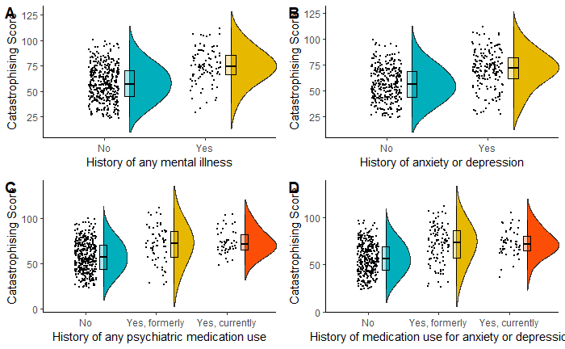

```r
data3_scores$medication_general<-recode(data3_scores$medication_general,"'No'= 1;'Yes I took medication in the past'=2;'Yes I currently take medication'= 3")
data3_scores$medication_anxdep<-recode(data3_scores$medication_anxdep,"'No'= 1;'Yes I took medication in the past'=2;'Yes I currently take medication'= 3")

data3_scores$diagnosis_general<-ifelse(data3_scores$diagnosis_general=='yes',2,1)
data3_scores$diagnosis_anxdep<-ifelse(data3_scores$diagnosis_anxdep=='yes',2,1)

data3_scores$diagnosis_general<-factor(data3_scores$diagnosis_general)
data3_scores$diagnosis_anxdep<-factor(data3_scores$diagnosis_anxdep)
data3_scores$medication_general<-factor(data3_scores$medication_general)
data3_scores$medication_anxdep<-factor(data3_scores$medication_anxdep)


a<-ggplot(data=data3_scores,aes(x=diagnosis_general,y=Cat,fill=diagnosis_general)) +
  geom_flat_violin(position = position_nudge(x = .25, y = 0),adjust =2, trim = FALSE)+
  geom_point(position = position_jitter(width = .15), size = .25)+
  geom_boxplot(aes(x = as.numeric(diagnosis_general)+0.25, y = Cat),outlier.shape = NA, alpha = 0.3, width = .1, colour = "BLACK") +
  labs(y='Catastrophising Score',x='History of any mental illness') +
  scale_fill_manual(values= c("#00AFBB", "#E7B800","#FC4E07"))+
  scale_x_discrete(breaks=c(1,2),labels=c('No','Yes'))+
  theme_classic()+
  theme(legend.position='none')

b<-ggplot(data=data3_scores,aes(x=diagnosis_anxdep,y=Cat,fill=diagnosis_anxdep)) +
  geom_flat_violin(position = position_nudge(x = .25, y = 0),adjust =2, trim = FALSE)+
  geom_point(position = position_jitter(width = .15), size = .25)+
  geom_boxplot(aes(x = as.numeric(diagnosis_anxdep)+0.25, y = Cat),outlier.shape = NA, alpha = 0.3, width = .1, colour = "BLACK") +
  labs(y='Catastrophising Score',x='History of anxiety or depression') +
  scale_fill_manual(values= c("#00AFBB", "#E7B800","#FC4E07"))+
  scale_x_discrete(breaks=c(1,2),labels=c('No','Yes'))+
  theme_classic()+
  theme(legend.position='none')

c<-ggplot(data=data3_scores,aes(x=medication_general,y=Cat,fill=medication_general)) +
  geom_flat_violin(position = position_nudge(x = .25, y = 0),adjust =2, trim = FALSE)+
  geom_point(position = position_jitter(width = .15), size = .25)+
  geom_boxplot(aes(x = as.numeric(medication_general)+0.25, y = Cat),outlier.shape = NA, alpha = 0.3, width = .1, colour = "BLACK") +
  labs(y='Catastrophising Score',x='History of any psychiatric medication use') +
  scale_fill_manual(values= c("#00AFBB", "#E7B800","#FC4E07"))+
  scale_x_discrete(breaks=c(1,2,3),labels=c('No','Yes, formerly','Yes, currently'))+
  theme_classic()+
  theme(legend.position='none')


d<-ggplot(data=data3_scores,aes(x=medication_anxdep,y=Cat,fill=medication_anxdep)) +
  geom_flat_violin(position = position_nudge(x = .25, y = 0),adjust =2, trim = FALSE)+
  geom_point(position = position_jitter(width = .15), size = .25)+
  geom_boxplot(aes(x = as.numeric(medication_anxdep)+0.25, y = Cat),outlier.shape = NA, alpha = 0.3, width = .1, colour = "BLACK") +
  labs(y='Catastrophising Score',x='History of medication use for anxiety or depression') +
  scale_x_discrete(breaks=c(1,2,3),labels=c('No','Yes, formerly','Yes, currently'))+
  scale_fill_manual(values= c("#00AFBB", "#E7B800","#FC4E07"))+
  theme_classic()+
  theme(legend.position='none')

plot_grid(a,b,c,d,labels='AUTO')
if (save_images==1){
  ggsave(file=paste0(workingdir,'/raincloud_plots.png'),height=9,width=12)
}
```

# Experiment 4

Load data

```r
data4<-read.csv(paste0(workingdir,'/experiment4.csv'))
```

Time taken

```r
cat_time_taken_t1<-mean(data4$cat_questionnaire_time_t1)
seconds_to_period(cat_time_taken_t1/1000)
```

```
[1] "2M 1.56209S"
```

```r
cat_time_taken_t2<-mean(data4$cat_questionnaire_time_t2)
seconds_to_period(cat_time_taken_t2/1000)
```

```
[1] "2M 14.3843S"
```

```r
full_time_taken<-mean(data4$total_time)
seconds_to_period(full_time_taken)
```

```
[1] "4M 42.8424S"
```

Test-retest correlation and plot

```r
cor(data4$score_t1,data4$score_t2)
```

```
[1] 0.7763464
```

```r
cor.test(data4$score_t1,data4$score_t2)
```

```
    Pearson's product-moment correlation

data:  data4$score_t1 and data4$score_t2
t = 12.193, df = 98, p-value < 2.2e-16
alternative hypothesis: true correlation is not equal to 0
95 percent confidence interval:
 0.6842718 0.8440557
sample estimates:
      cor
0.7763464
```

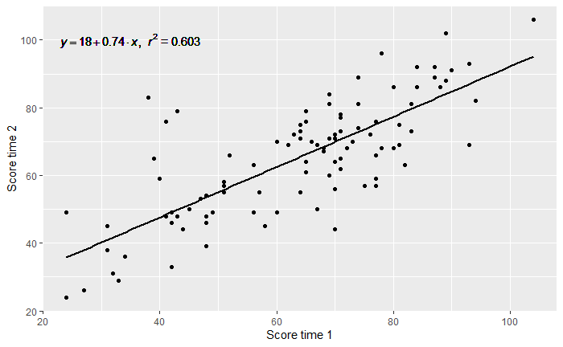

```r
#function for getting the regression equation as text
lm_eqn <- function(x,y){
    m <- lm(y ~ x);
    eq <- substitute(italic(y) == a + b %.% italic(x)*","~~italic(r)^2~"="~r2,
         list(a = format(unname(coef(m)[1]), digits = 2),
              b = format(unname(coef(m)[2]), digits = 2),
             r2 = format(summary(m)$r.squared, digits = 3)))
    as.character(as.expression(eq));
}


ggplot(data=data4,aes(x=score_t1,y=score_t2))+
  geom_point()+
  labs(x='Score time 1',y='Score time 2')+
  geom_smooth(method = "lm", se=FALSE, color="black", formula = y ~ x)+
  geom_text(x = 35, y = 100, label = lm_eqn(data4$score_t1,data4$score_t2), parse = TRUE)
```

```r
NA
NA
```

Calculate ICC (A,1) and (C,1) for absolute agreement and consistency (runs two-way mixed ICC analyses)

```r
icc_a1<-icc(cbind(data4$score_t1,data4$score_t2),model = "twoway",
    type = "agreement",
    unit = "single",
    r0 = 0,
    conf.level = 0.95)

icc_a1
```

```
 Single Score Intraclass Correlation

   Model: twoway
   Type : agreement

   Subjects = 100
     Raters = 2
   ICC(A,1) = 0.774

 F-Test, H0: r0 = 0 ; H1: r0 > 0
 F(99,99.7) = 7.91 , p = 6.54e-22

 95%-Confidence Interval for ICC Population Values:
  0.682 < ICC < 0.842
```

```r
icc_c1<-icc(cbind(data4$score_t1,data4$score_t2),model = "twoway",
    type = "consistency",
    unit = "single",
    r0 = 0,
    conf.level = 0.95)

icc_c1
```

```
 Single Score Intraclass Correlation

   Model: twoway
   Type : consistency

   Subjects = 100
     Raters = 2
   ICC(C,1) = 0.776

 F-Test, H0: r0 = 0 ; H1: r0 > 0
   F(99,99) = 7.91 , p = 8.45e-22

 95%-Confidence Interval for ICC Population Values:
  0.684 < ICC < 0.843
```

Alpha, omega, inter-item and item-total correlations

```r
data4_items<-select(data4,contains('t2'))%>%select(contains('X'))

#alpha
psych::alpha(x=data4_items)
```

```
Reliability analysis
Call: psych::alpha(x = data4_items)
```

|  | raw_alpha | std.alpha | G6(smc) | average_r | S/N | ase | mean | sd | median_r |
| --- | --- | --- | --- | --- | --- | --- | --- | --- | --- |
|  | 0.9438945 | 0.9445307 | 0.9610135 | 0.4150335 | 17.02799 | 0.008104381 | 2.71125 | 0.7199911 | 0.4011799 |

```
 lower alpha upper     95% confidence boundaries
0.93 0.94 0.96

 Reliability if an item is dropped:
```

|  | raw_alpha | std.alpha | G6(smc) | average_r | S/N | alpha se | var.r | med.r |
| --- | --- | --- | --- | --- | --- | --- | --- | --- |
| X1_t2 | 0.9410323 | 0.9416427 | 0.9584736 | 0.4123031 | 16.13582 | 0.008525795 | 0.009861180 | 0.4003204 |
| X2_t2 | 0.9415662 | 0.9422211 | 0.9580597 | 0.4148680 | 16.30737 | 0.008444408 | 0.009626232 | 0.4075944 |
| X3_t2 | 0.9413249 | 0.9419880 | 0.9585432 | 0.4138306 | 16.23781 | 0.008482848 | 0.009529900 | 0.4014183 |
| X4_t2 | 0.9403395 | 0.9408775 | 0.9572447 | 0.4089535 | 15.91403 | 0.008622858 | 0.008712748 | 0.4005857 |
| X5_t2 | 0.9406025 | 0.9412885 | 0.9578970 | 0.4107465 | 16.03244 | 0.008589832 | 0.009673980 | 0.4003204 |
| X6_t2 | 0.9405546 | 0.9412726 | 0.9580492 | 0.4106768 | 16.02782 | 0.008598000 | 0.009841598 | 0.3984770 |
| X7_t2 | 0.9430529 | 0.9437175 | 0.9588239 | 0.4216386 | 16.76752 | 0.008233522 | 0.009205468 | 0.4105295 |
| X8_t2 | 0.9425708 | 0.9432714 | 0.9602153 | 0.4195992 | 16.62779 | 0.008305307 | 0.010065670 | 0.4092042 |
| X9_t2 | 0.9421807 | 0.9427404 | 0.9583369 | 0.4171950 | 16.46432 | 0.008347775 | 0.009841903 | 0.4075984 |
| X10_t2 | 0.9420321 | 0.9425581 | 0.9594379 | 0.4163755 | 16.40890 | 0.008385879 | 0.010088829 | 0.4075944 |

[output cut: 14 more lines]

```
 Item statistics
```

|  | n | raw.r | std.r | r.cor | r.drop | mean | sd |
| --- | --- | --- | --- | --- | --- | --- | --- |
| X1_t2 | 100 | 0.7028727 | 0.7062996 | 0.6940030 | 0.6714723 | 2.88 | 1.0078480 |
| X2_t2 | 100 | 0.6623978 | 0.6655104 | 0.6558197 | 0.6255152 | 3.46 | 1.0676132 |
| X3_t2 | 100 | 0.6808900 | 0.6820068 | 0.6702410 | 0.6433983 | 3.24 | 1.1292261 |
| X4_t2 | 100 | 0.7560851 | 0.7595681 | 0.7585950 | 0.7296420 | 3.56 | 0.9981802 |
| X5_t2 | 100 | 0.7314970 | 0.7310530 | 0.7235515 | 0.7010375 | 2.35 | 1.0576799 |
| X6_t2 | 100 | 0.7325467 | 0.7321625 | 0.7234040 | 0.7003871 | 2.63 | 1.1160446 |
| X7_t2 | 100 | 0.5594481 | 0.5578375 | 0.5412833 | 0.5130239 | 2.37 | 1.1069569 |
| X8_t2 | 100 | 0.5912770 | 0.5902700 | 0.5640277 | 0.5480882 | 2.44 | 1.0854408 |
| X9_t2 | 100 | 0.6325062 | 0.6285034 | 0.6167449 | 0.5872918 | 2.46 | 1.2178803 |
| X10_t2 | 100 | 0.6472923 | 0.6415369 | 0.6217270 | 0.6017212 | 2.77 | 1.2621530 |

[output cut: 14 more lines]

```
Non missing response frequency for each item
          1    2    3    4    5 miss
X1_t2  0.07 0.31 0.34 0.23 0.05    0
X2_t2  0.06 0.10 0.32 0.36 0.16    0
X3_t2  0.08 0.16 0.34 0.28 0.14    0
X4_t2  0.02 0.13 0.30 0.37 0.18    0
X5_t2  0.23 0.37 0.25 0.12 0.03    0
X6_t2  0.16 0.34 0.26 0.19 0.05    0
X7_t2  0.25 0.34 0.23 0.15 0.03    0
X8_t2  0.23 0.31 0.27 0.17 0.02    0
X9_t2  0.27 0.27 0.26 0.13 0.07    0
X10_t2 0.18 0.27 0.27 0.16 0.12    0
X11_t2 0.14 0.17 0.36 0.22 0.11    0
X12_t2 0.11 0.23 0.36 0.26 0.04    0
X13_t2 0.26 0.26 0.34 0.13 0.01    0
X14_t2 0.10 0.21 0.30 0.27 0.12    0
X15_t2 0.17 0.33 0.33 0.13 0.04    0
X16_t2 0.25 0.38 0.19 0.16 0.02    0
X17_t2 0.12 0.27 0.36 0.19 0.06    0
X18_t2 0.08 0.27 0.31 0.29 0.05    0
X19_t2 0.11 0.29 0.39 0.19 0.02    0
X20_t2 0.24 0.41 0.21 0.12 0.02    0
X21_t2 0.17 0.28 0.35 0.15 0.05    0
X22_t2 0.35 0.34 0.20 0.09 0.02    0
X23_t2 0.18 0.32 0.25 0.20 0.05    0
X24_t2 0.17 0.32 0.28 0.19 0.04    0
```

```
Omega
Call: omegah(m = m, nfactors = nfactors, fm = fm, key = key, flip = flip,
    digits = digits, title = title, sl = sl, labels = labels,
    plot = plot, n.obs = n.obs, rotate = rotate, Phi = Phi, option = option,
    covar = covar)
Alpha:                 0.94
G.6:                   0.96
Omega Hierarchical:    0.75
Omega H asymptotic:    0.79
Omega Total            0.95

Schmid Leiman Factor loadings greater than  0.2
```

|  | g | F1* | F2* | F3* | h2 | u2 | p2 |
| --- | --- | --- | --- | --- | --- | --- | --- |
| X1_t2 | 0.63 | 0.24 |  | 0.21 | 0.50 | 0.50 | 0.78 |
| X2_t2 | 0.61 | 0.36 |  |  | 0.51 | 0.49 | 0.73 |
| X3_t2 | 0.63 | 0.37 |  |  | 0.54 | 0.46 | 0.74 |
| X4_t2 | 0.72 | 0.44 |  |  | 0.76 | 0.24 | 0.69 |
| X5_t2 | 0.63 |  | 0.36 |  | 0.56 | 0.44 | 0.72 |
| X6_t2 | 0.63 |  | 0.36 |  | 0.55 | 0.45 | 0.72 |
| X7_t2 | 0.45 |  | 0.44 |  | 0.42 | 0.58 | 0.49 |
| X8_t2 | 0.48 |  | 0.30 |  | 0.33 | 0.67 | 0.70 |
| X9_t2 | 0.52 |  | 0.20 | 0.56 | 0.62 | 0.38 | 0.44 |
| X10_t2 | 0.55 |  |  |  | 0.39 | 0.61 | 0.80 |

[output cut: 14 more lines]

```
With eigenvalues of:
  g F1* F2* F3*
8.1 1.2 1.7 1.1

general/max  4.74   max/min =   1.56
mean percent general =  0.67    with sd =  0.13 and cv of  0.2
Explained Common Variance of the general factor =  0.67

The degrees of freedom are 207  and the fit is  2.84
The number of observations was  100  with Chi Square =  250.06  with prob <  0.022
The root mean square of the residuals is  0.05
The df corrected root mean square of the residuals is  0.05
RMSEA index =  0.044  and the 10 % confidence intervals are  0.019 0.065
BIC =  -703.21

Compare this with the adequacy of just a general factor and no group factors
The degrees of freedom for just the general factor are 252  and the fit is  4.6
The number of observations was  100  with Chi Square =  411.63  with prob <  8.4e-10
The root mean square of the residuals is  0.11
The df corrected root mean square of the residuals is  0.12

RMSEA index =  0.079  and the 10 % confidence intervals are  0.066 0.094
BIC =  -748.87

Measures of factor score adequacy
                                                 g   F1*  F2*  F3*
Correlation of scores with factors            0.88  0.61 0.76 0.82
Multiple R square of scores with factors      0.77  0.37 0.58 0.68
Minimum correlation of factor score estimates 0.54 -0.25 0.16 0.35

 Total, General and Subset omega for each subset
                                                 g  F1*  F2*  F3*
Omega total for total scores and subscales    0.95 0.89 0.88 0.78
Omega general for total scores and subscales  0.75 0.73 0.58 0.33
Omega group for total scores and subscales    0.11 0.16 0.30 0.45
```

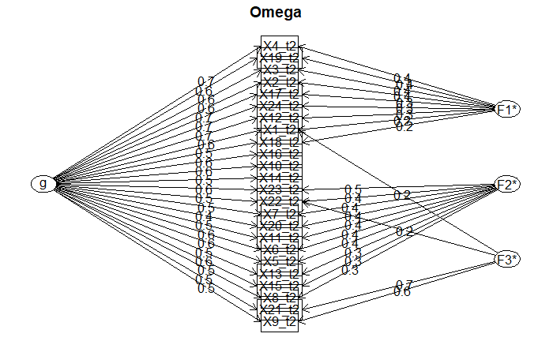

```r
#omega
psych::omega(data4_items)
```

```r
#inter-item correlation
data_correlation4 <- data4_items %>% corrr::correlate()
```

```
Correlation method: 'pearson'
Missing treated using: 'pairwise.complete.obs'
```

```r
data_correlation4 <- data_correlation4 %>% dplyr::select(-rowname) %>% colMeans(na.rm = TRUE)
data_correlation4
```

```
    X1_t2     X2_t2     X3_t2     X4_t2     X5_t2     X6_t2     X7_t2     X8_t2     X9_t2    X10_t2    X11_t2
0.4450682 0.4168544 0.4282649 0.4819140 0.4621901 0.4629576 0.3423772 0.3648107 0.3912567 0.4002720 0.3892565
   X12_t2    X13_t2    X14_t2    X15_t2    X16_t2    X17_t2    X18_t2    X19_t2    X20_t2    X21_t2    X22_t2
0.4877158 0.3870628 0.3744028 0.4541942 0.4002130 0.4625043 0.3883931 0.4265234 0.2972207 0.3704265 0.4166743
   X23_t2    X24_t2
0.4378965 0.4723543
```

```r
mean(data_correlation4)
```

```
[1] 0.4150335
```

[figure not shown]

```r
data.frame(data_correlation4) %>%
  ggplot2::ggplot(aes(x = data_correlation4)) +
  geom_histogram(bins = 10, alpha = .5) +
  geom_vline(xintercept = mean(data_correlation4), color = "red") +
  xlab("Mean inter-item correlation") +
  theme_bw()
```

```r
#item-total correlation
data4_items$score<-rowSums(data4_items)
total_correlation4 <- data4_items %>% corrr::correlate() %>% corrr::focus(score)
```

```
Correlation method: 'pearson'
Missing treated using: 'pairwise.complete.obs'
```

```r
mean(total_correlation4$score)
```

```
[1] 0.6628151
```

EFA

```r
data4_items<- data4_items %>% dplyr::select(-'score')

psych::KMO(data4_items)
```

```
Kaiser-Meyer-Olkin factor adequacy
Call: psych::KMO(r = data4_items)
Overall MSA =  0.9
MSA for each item =
 X1_t2  X2_t2  X3_t2  X4_t2  X5_t2  X6_t2  X7_t2  X8_t2  X9_t2 X10_t2 X11_t2 X12_t2 X13_t2 X14_t2 X15_t2
  0.92   0.87   0.92   0.91   0.91   0.92   0.81   0.94   0.86   0.93   0.84   0.91   0.90   0.88   0.91
X16_t2 X17_t2 X18_t2 X19_t2 X20_t2 X21_t2 X22_t2 X23_t2 X24_t2
  0.93   0.94   0.90   0.91   0.79   0.86   0.87   0.90   0.88
```

```r
temp<-round(cor(data4_items),2)
cortest.bartlett(temp,n=nrow(data4_items))
```

```
$chisq
[1] 1343.48

$p.value
[1] 9.827336e-140

$df
[1] 276
```

```
Parallel analysis suggests that the number of factors =  1  and the number of components =  NA
```

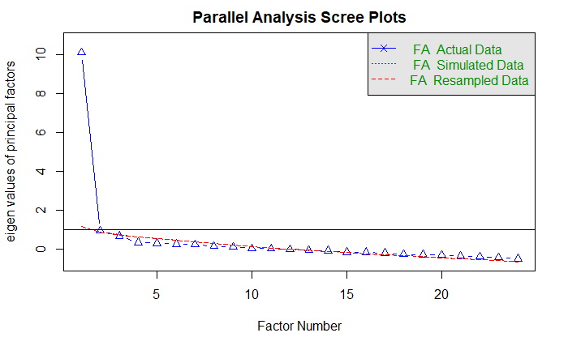

```r
parallel <- fa.parallel(data4_items, fm = 'minres', fa = 'fa')
```

```r
onefactor4 <- fa(data4_items,nfactors = 1,rotate = "oblimin",fm="minres")
print(onefactor4)
```

```
Factor Analysis using method =  minres
Call: fa(r = data4_items, nfactors = 1, rotate = "oblimin", fm = "minres")
Standardized loadings (pattern matrix) based upon correlation matrix
```

|  | MR1 | h2 | u2 | com |
| --- | --- | --- | --- | --- |
| X1_t2 | 0.69 | 0.4827786 | 0.5172214 | 1 |
| X2_t2 | 0.65 | 0.4226871 | 0.5773129 | 1 |
| X3_t2 | 0.67 | 0.4508586 | 0.5491414 | 1 |
| X4_t2 | 0.76 | 0.5794595 | 0.4205405 | 1 |
| X5_t2 | 0.72 | 0.5206838 | 0.4793162 | 1 |
| X6_t2 | 0.72 | 0.5183591 | 0.4816409 | 1 |
| X7_t2 | 0.53 | 0.2757084 | 0.7242916 | 1 |
| X8_t2 | 0.56 | 0.3111389 | 0.6888611 | 1 |
| X9_t2 | 0.60 | 0.3585785 | 0.6414215 | 1 |
| X10_t2 | 0.62 | 0.3847244 | 0.6152756 | 1 |

[output cut: 14 more lines]

```
                 MR1
SS loadings    10.11
Proportion Var  0.42

Mean item complexity =  1
Test of the hypothesis that 1 factor is sufficient.

The degrees of freedom for the null model are  276  and the objective function was  14.84 with Chi Square of  1337.79
The degrees of freedom for the model are 252  and the objective function was  4.34

The root mean square of the residuals (RMSR) is  0.07
The df corrected root mean square of the residuals is  0.07

The harmonic number of observations is  100 with the empirical chi square  274.57  with prob <  0.16
The total number of observations was  100  with Likelihood Chi Square =  388.39  with prob <  7.2e-08

Tucker Lewis Index of factoring reliability =  0.858
RMSEA index =  0.073  and the 90 % confidence intervals are  0.059 0.088
BIC =  -772.12
Fit based upon off diagonal values = 0.97
Measures of factor score adequacy
                                                   MR1
Correlation of (regression) scores with factors   0.97
Multiple R square of scores with factors          0.95
Minimum correlation of possible factor scores     0.90
```